# Multi-Omics Data Analysis Notebook

CNSB

2019-10-23

========================================================

```r
##  SET FILE PATHS FOR LOCAL INSTALL

## R libraries path
#libraries_path = '/project/cnsbomic/Tools/R'

## Inherit paths
#inherit_paths = "TRUE"

# Loaded from Parameters.R

## IF NOT RUNNING WITH PIPELINE, SET WORKING DIRECTORY
# working_dir <- PATH TO DATA FILES
# setwd(working_dir)

# Databases for enrichR search
search_databases <- c("KEGG_2016", "GO_Biological_Process_2017b", #"GO_Cellular_Component_2017b",
                      "GO_Molecular_Function_2017b", "HMDB_Metabolites", "Reactome_2016",
                      "MSigDB_Oncogenic_Signatures");

debug_opt <- FALSE
source("Parameters.R")
```

```r
project_name <- 'Analysis';
working_dir <- '/projectnb/cnsbomic/ben/onepot/mda_glucose'; # Directory for analysis and where data is
annotation_filename <- '/projectnb/cnsbomic/ben/onepot/mda_glucose/Annotation_3.xlsx';
query_web <- TRUE;
map_color <- 'viridis';
zero_percent <- 0.70;
norm_method <- 'quantile';
shinyNorm <- FALSE;
saveXlsx <- TRUE;
runDifferential <- TRUE;
adjpcutoff <- 0.05;
sig_percent <- 0.010;
enrichr_section <- TRUE;
gsea_section <- TRUE;
all_comparisons <- TRUE;
species <- 'Human (9606)';
enrichmentmap_p_val <- 0.05;
enrichmentmap_q_val <- 0.30;
use_site_norm <- FALSE;
int_heatmap_section <- FALSE;
int_volcano_section <- TRUE;
txtFolder <- FALSE;
notebook_dir <- '/project/cnsbomic/Omics_Notebook/src';
inherit_paths <- TRUE;
libraries_path <- '/project/cnsbomic/Tools/R3.6';
gsea_jar <- '/project/cnsbomic/Tools/gsea-3.0.jar';
```

```r
# Make output subdirectories
output_subdir <- paste( gsub("\\.","", make.names(project_name)), gsub("-","",Sys.Date()), sep="_")
output_files_subdir <- paste(output_subdir,"Files", sep="/")
output_plots_subdir <- paste(output_subdir,"Plots", sep="/")
output_path <- file.path(working_dir, output_subdir)
output_files_path <- file.path(working_dir, output_files_subdir)
output_plots_path <- file.path(working_dir, output_plots_subdir)
output_contrast_path <- output_plots_path
if( dir.exists(output_path) == FALSE ) {dir.create(output_path)}
if( dir.exists(output_files_path) == FALSE ) {dir.create(output_files_path)}
if( dir.exists(output_plots_path) == FALSE ) {dir.create(output_plots_path)}

# Set library path for BU SCC
if(inherit_paths==TRUE) { .libPaths(libraries_path) }

# Load pipeline libraries
suppressPackageStartupMessages({
library(R.utils)
library(matrixStats)
library(Biobase)
library(limma)
library(splines)
library(knitr)
library(ggplot2)
library(ggrepel)
library(calibrate)
library(preprocessCore)
library(RColorBrewer)
library(viridis)
library(reshape2)
library(tidyr)
library(dplyr)
library(stringr)
library(grid)
library(gridExtra)
library(lattice)
library(VennDiagram)
library(UpSetR)
library(corrplot)
library(heatmaply)
library(scales)
library(edgeR)
library(Glimma)
library(openxlsx)
library(ComplexHeatmap)
library(RCurl)
library(fgsea)
library(BiocParallel)
register(SerialParam())

if(enrichr_section){ library(enrichR) }

if(gsea_section){
  library(httr)
  library(RJSONIO)
  library(RCy3)
  #library(EasycyRest)
}

#library(sva) # combat/batch correction
#library(hmdbQuery) # metabolite annotation info
})

# Source function file
sourceDirectory(file.path(gsub("src","R", notebook_dir)))
```

# Load Search Output and Process

```r
############################################
# The omicsList object is a list of lists. Each top level represents a different omics type.
#
# omicsList[[i]][[1]] "dataType" is the name of the omics set
# omicsList[[i]][[2]] "dataFormat" is the data format of the omics set.
# omicsList[[i]][[3]] "filename" is the filename/path for the omics data set.
# omicsList[[i]][[4]] "RawData" is the raw data.
# omicsList[[i]][[5]] "eSet" is the working eset object
# omicsList[[i]][[6]] "topVariable" is the index of the most variable features
# omicsList[[i]][[7]] "fit" is the limmaFit output of eBayes
# omicsList[[i]][[8]]
# omicsList[[i]][[9]]
# omicsList[[i]][[10]] "siteNorm" is site data normalized to protein groups
# omicsList[[i]][[11]]
# omicsList[[i]][[12]] "prebatch_eset" is the normalized but pre-batch corrected eset, if applicable
# omicsList[[i]][[14]] is the un-normalized eset object - for debugging only
#
############################################

# Make index variables
metab_data_index <- c();  # index of all Metabolite data
mz_data_index <- c();     # index of all data with mz
phos_data_index <- c();   # index of Phospho Site Data (from MQ)
sites_data_index <- c();  # index of all site data (from MQ)
sites_norm_index <- c();  # index of site data normalized to proteome (if applicable)
gene_data_index <- c();   # index of all data  with Gene (HGNC Symbols)
prot_data_index <- c();   # index of all data with Protein (Uniprot IDs)
prot_groups_index <- c(); # index of all Protein Groups Data (MQ)

# Import annotation file
if(!file.exists(annotation_filename)){
  print(paste("Annotation file not found: ",annotation_filename,sep=""))
  stop()
}
annot <- data.frame(openxlsx::read.xlsx(annotation_filename, 1, colNames=FALSE)); # read annotation
contrastgroups <- gsub("\\.","", make.names(na.omit(t(annot[1,-1:-3]))));
annot<-annot[c(-1,-4),];

# Make omicsList object
omicsList <- vector("list", (nrow(annot)-2) )

for (i in 1:(nrow(annot)-2) ){
  omicsList[[i]] <- vector("list", 14);
  omicsList[[i]][1] <- make.names(annot[i+2,1]);
  names(omicsList[[i]])[1] <- gsub("\\.","", make.names("dataType"));
  omicsList[[i]][2] <- make.names(annot[i+2,2]);
  names(omicsList[[i]])[2] <- "dataFormat";
  if(grepl("Metabolites", omicsList[[i]][["dataFormat"]]) ){ metab_data_index <- c(metab_data_index, i)  };
  if(omicsList[[i]][["dataFormat"]]=="Phospho.Sites..MQ."){ phos_data_index <- c(phos_data_index, i)  };
  if(any(omicsList[[i]][["dataFormat"]] %in% c("Protein.Groups..MQ.", "Peptides..MQ.")) ){ prot_groups_index <- c(prot_groups_index, i) };
  if(grepl(".Sites..MQ.",omicsList[[i]][["dataFormat"]]) ){ sites_data_index <- c(sites_data_index, i)  };
  omicsList[[i]][[3]] <- annot[i+2,3];
  names(omicsList[[i]])[3] <- "filename";
}

# Format annotation table
annot[3:nrow(annot),3] <- annot[3:nrow(annot),1];
annot <- t(annot[,-1:-2]);
rownames(annot) <- NULL;
colnames(annot)<-make.unique(annot[1,]);
annot<-data.frame((annot[-1,]));
annot[,"Group"]<-gsub("\\.","",make.names(annot[,"Group"]))
annot[,"SampleName"]<-gsub("\\.","",make.names(make.unique(as.character(annot[,"SampleName"]))))

# Get batch information if there
try({
  annot2 <- openxlsx::read.xlsx(annotation_filename, 2, colNames=FALSE, rowNames=TRUE)
  annot2 <- data.frame(t(annot2))
  rownames(annot2) <- NULL;
  annot <- data.frame(cbind(annot, annot2))
}, silent=TRUE)

# Add file paths to file names (w/chanbge for generating txt report)
for (i in 1:length(omicsList)){
  if( (grepl(".MQ.", omicsList[[i]][["dataFormat"]]) & txtFolder==TRUE) ) {
    omicsList[[i]][[3]] <- file.path(working_dir, "txt", omicsList[[i]][[3]])
  } else {
    omicsList[[i]][[3]] <- file.path(working_dir, omicsList[[i]][[3]])
  }
}

# Import data and make eset objects
for (i in 1:length(omicsList)){

  if( grepl(".csv$", omicsList[[i]][[3]]) ) { file_ext_sep <- ","; } else { file_ext_sep <- "\t"; }

  if(!file.exists(omicsList[[i]][[3]])){ stop(paste("File not found: ",omicsList[[i]][[3]],sep="")) }

  omicsList[[i]][[4]] <- data.frame(read.delim(omicsList[[i]][[3]], header=TRUE, stringsAsFactors=FALSE,
                                               sep=file_ext_sep, check.names=FALSE));
  names(omicsList[[i]])[4] <- "RawData";

  tryCatch({

    omicsList[[i]][[5]] <- makeEset(data=omicsList[[i]][[4]], annotate=annot, type=omicsList[[i]][[1]],
                                    log_transform=(norm_method!="none") ,
                                    data_format=omicsList[[i]][[2]], uniprot_annotation=query_web);
    }, error=function(e){
      stop(paste("Problem with input data format:", e));
    })

  names(omicsList[[i]])[5] <- "eSet";
  if(debug_opt == TRUE ) { omicsList[[i]][[14]] <- omicsList[[i]][[5]] }# use for debugging

  if( "Gene" %in% colnames(fData(omicsList[[i]][["eSet"]])) ) { gene_data_index <- c(gene_data_index, i) };
  if( "Protein" %in% colnames(fData(omicsList[[i]][["eSet"]])) ) { prot_data_index <- c(prot_data_index, i) };
  if( "mz" %in% colnames(fData(omicsList[[i]][["eSet"]])) ) { mz_data_index <- c(mz_data_index, i) };
}

# load libraries if needed
suppressPackageStartupMessages({suppressWarnings({
if( length(phos_data_index)>0 ){
  library(KSEAapp)
}
if( length(metab_data_index)>0 ){
  library(MetaboAnalystR)
}
}) })
```

# QC and Exploratory Analysis

```r
# if txt folder provided, generate PTXQC report
tryCatch(expr={
if(txtFolder){
  library(PTXQC)
  require(methods)
  library(data.table)

  txt_folder <- file.path(working_dir, "txt");
  report.mq <- createReport(txt_folder);
}
}, error=function(e){print("Error generating PTXQC report")} )
```

### Data Normalization

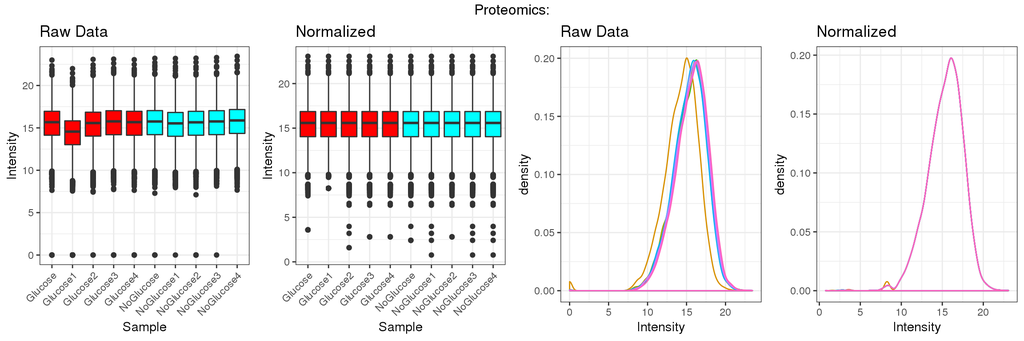

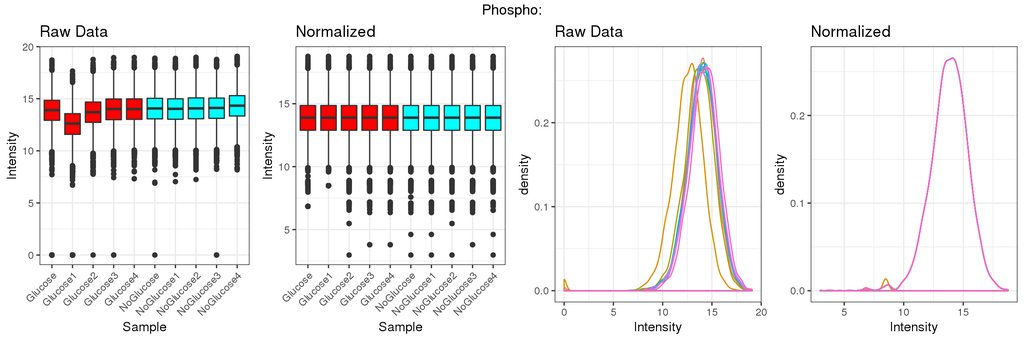

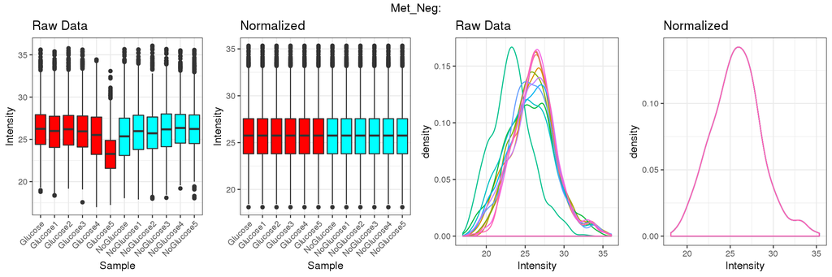

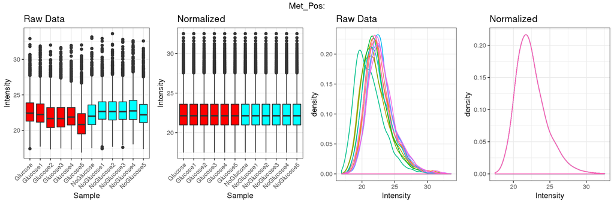

```r
pca_output <- vector("list", length(omicsList) )
output_links<-"";

for(i in 1:length(omicsList)){
  if(length(zero_percent)==1){use_zero<-zero_percent}else{use_zero<-zero_percent[i]}
  if(length(norm_method)==1){use_norm<-norm_method}else{use_norm<-norm_method[i]}

  if(debug_opt){ index<-14 } else { index <- 5 }
  omicsList[[i]][[5]] <-intensityNorm(eset=omicsList[[i]][[index]],
                                      type=omicsList[[i]][[1]],
                                      data_format=omicsList[[i]][["dataFormat"]],
                                      norm=norm_method, cutoff=zero_percent)

  # Make output hyperlinks for markdown
  add_link <- paste("[ ",omicsList[[i]][["dataType"]], ": Boxplot/Dist. ](", output_plots_subdir,
                    "/boxplot_histogram_",omicsList[[i]][["dataType"]],".pdf)", sep="")
  output_links <- paste(output_links, add_link, sep=" | " )

  # Batch correction
  if("Batch" %in% colnames(pData(omicsList[[i]][["eSet"]])) & !("Met" %in% omicsList[[i]][["dataFormat"]])) { try({
    suppressPackageStartupMessages({require(sva) });
    suppressMessages({ suppressWarnings({
    omicsList[[i]][[12]] <- omicsList[[i]][["eSet"]]
    names(omicsList[[i]])[12] <- "prebatch_eset"

    pheno = pData(omicsList[[i]][["eSet"]])
    edata = exprs(omicsList[[i]][["eSet"]])
    batch = pheno$Batch

    modcombat = model.matrix(~1, data=pheno)
    combat_edata = ComBat(dat=edata, batch=batch, mod=modcombat, par.prior=TRUE, prior.plots=FALSE)
    combat_eset = ExpressionSet(assayData=combat_edata)
    pData(combat_eset) = pData(omicsList[[i]][["eSet"]])
    fData(combat_eset) = fData(omicsList[[i]][["eSet"]])
    })})
    omicsList[[i]][["eSet"]] <- combat_eset
    tmp<-drawPCA(eset=omicsList[[i]][["prebatch_eset"]], type=paste(omicsList[[i]][["dataType"]],"_precorrection", sep=""));
  }) }

  # PCA plots
  pca_output[[i]] <- drawPCA(eset=omicsList[[i]][["eSet"]], type=omicsList[[i]][["dataType"]])

  # Make output hyperlinks for markdown
  add_link <- paste("[ ",omicsList[[i]][["dataType"]], ": PCA ](", output_plots_subdir,"/PCAplots_",omicsList[[i]][["dataType"]],".pdf)", sep="")
  output_links <- paste(output_links, add_link, sep=" | " )
  output_links <- paste(output_links, "  \n", sep="" )
}
```

```r
print_report <- c();
for(i in 1:length(omicsList)){
    print_report <- c(print_report, paste(omicsList[[i]][[1]],": ",nrow(omicsList[[i]][[4]])," features detected in raw data. \n",sep=""),
                      paste(omicsList[[i]][[1]],": ",nrow(omicsList[[i]][[5]])," features detected in filtered data. \n",sep="") )
}

cat(print_report)
```

```
## Proteomics: 7439 features detected in raw data.
##  Proteomics: 7214 features detected in filtered data.
##  Phospho: 6637 features detected in raw data.
##  Phospho: 5785 features detected in filtered data.
##  Met_Neg: 1495 features detected in raw data.
##  Met_Neg: 1495 features detected in filtered data.
##  Met_Pos: 2574 features detected in raw data.
##  Met_Pos: 2574 features detected in filtered data.
```

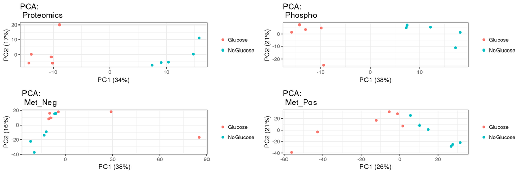

```r
writeLines(print_report, con=file.path(output_files_path, "Feature_Numbers.txt"))

grid.arrange(grobs=pca_output, ncol=2)
```

Click to view full size images:  
| Proteomics: Boxplot/Dist. | Proteomics: PCA  
| Phospho: Boxplot/Dist. | Phospho: PCA  
| Met_Neg: Boxplot/Dist. | Met_Neg: PCA  
| Met_Pos: Boxplot/Dist. | Met_Pos: PCA

### Venn Diagram

```r
output_links <-"";

if( length(gene_data_index) > 1 ){
  gene_list <- vector("list", length(gene_data_index))
  for(i in 1:length(gene_data_index)){
    gene_list[[i]] <- fData(omicsList[[ gene_data_index[i] ]][["eSet"]])$Gene
    names(gene_list)[i] <- omicsList[[ gene_data_index[i] ]][["dataType"]]
  }
  drawVenn(item_list=gene_list, item_name="Genes")
  add_link <- paste("[ Genes ](", output_plots_subdir,"/VennDiagram_Genes.pdf)", sep="")
  output_links <- paste(output_links, add_link, sep=" | " )
}

if( length(prot_data_index) > 1 ){
  prot_list <- vector("list", length(prot_data_index))
  for(i in 1:length(prot_data_index)){
    prot_list[[i]] <- fData(omicsList[[ prot_data_index[i] ]][["eSet"]])$Protein
    names(prot_list)[i] <- omicsList[[ prot_data_index[i] ]][["dataType"]]
  }
  drawVenn(prot_list, "Proteins")
  add_link <- paste("[ Proteins ](", output_plots_subdir,"/VennDiagram_Proteins.pdf)", sep="")
  output_links <- paste(output_links, add_link, sep=" | " )
}

if( length(mz_data_index) > 1 ){
  mz_list <- vector("list", length(mz_data_index))
  for(i in 1:length(mz_data_index)){
    mz_list[[i]] <- na.omit(round(fData(omicsList[[ mz_data_index[i] ]][["eSet"]])$mz,digits=2))
    names(mz_list)[i] <- omicsList[[ mz_data_index[i] ]][["dataType"]]
  }
  drawVenn(mz_list, "Metabolites_mz")
  add_link <- paste("[ Metabolites (mz) ](", output_plots_subdir,"/VennDiagram_Metabolites_mz.pdf)", sep="")
  output_links <- paste(output_links, add_link, sep=" | " )
}
```

Click to view full size overlap plots: | Genes | Proteins | Metabolites (mz)

### XY Correlation - Across Datasets

```r
output_links <-"";

# If there's a directory called "Subset_Lists" make feature lists based on text files
subset_genes=FALSE;
if( dir.exists("Subset_Lists") ){ try({
  filelist <- list.files(path=file.path("Subset_Lists"), pattern="*.txt")
  subset_genes <- vector("list", length=length(filelist))
  names(subset_genes) <- gsub("*.txt", "", filelist)

  for( i in 1:length(filelist)){
    subset_genes[i] <- unique(list(scan(file.path("Subset_Lists", filelist[i]), what="", sep=" " ) ))
  }
}) }

# Correlation for "Genes"
if(length(gene_data_index)>1){ try({
  item_name <- "Gene"
  data_index <- gene_data_index

  gene_values <- vector("list", length(data_index))
  for (i in 1:(length(gene_data_index)) ){
    gene_values[[i]] <- data.frame( exprs(omicsList[[ data_index[i] ]][["eSet"]]) ); # Make a data frame of values and genes
    gene_values[[i]][,item_name] <- fData(omicsList[[ data_index[i] ]][["eSet"]])[,item_name] ;
    gene_values[[i]] <- gene_values[[i]] %>% gather(sample, value, -item_name); # Gather values and get average by gene
    gene_values[[i]] <- gene_values[[i]] %>% group_by(.dots=item_name) %>% summarize(mean=mean(value));
    gene_values[[i]] <- gene_values[[i]][gene_values[[i]][,item_name]!="",]
    names(gene_values)[i] <- omicsList[[ data_index[i] ]][["dataType"]]
  }
  drawXYCorr(item_list=gene_values, item_name=item_name, subset_genes=subset_genes);
  add_link <- paste("[ ",item_name," Correlation Plots ](",output_plots_subdir,"/Correlation_Plots_",item_name,"_.pdf)", sep="") ;
  output_links <- paste(output_links, add_link, sep=" | " )
}) }

# Correlation for "Protein"
if(length(prot_data_index)>1){ try({
  item_name <- "Protein"
  data_index <- prot_data_index

  gene_values <- vector("list", length(data_index))
  for (i in 1:(length(gene_data_index)) ){
    gene_values[[i]] <- data.frame( exprs(omicsList[[ data_index[i] ]][["eSet"]]) ); # Make a data frame of values and genes
    gene_values[[i]][,item_name] <- fData(omicsList[[ data_index[i] ]][["eSet"]])[,item_name] ;
    gene_values[[i]] <- gene_values[[i]] %>% gather(sample, value, -item_name); # Gather values and get average by gene
    gene_values[[i]] <- gene_values[[i]] %>% group_by(.dots=item_name) %>% summarize(mean=mean(value));
    gene_values[[i]] <- gene_values[[i]][gene_values[[i]][,item_name]!="",]
    names(gene_values)[i] <- omicsList[[ data_index[i] ]][["dataType"]]
  }
  drawXYCorr(item_list=gene_values, item_name=item_name);
  add_link <- paste("[ ",item_name," Correlation Plots ](",output_plots_subdir,"/Correlation_Plots_",item_name,"_.pdf)", sep="");
  output_links <- paste(output_links, add_link, sep=" | " )
}) }
```

Click to view full size correlation plots: | Gene Correlation Plots | Protein Correlation Plots

### XY Correlation - Across Sample Groups

```r
output_links <-"";

for(i in 1:length(omicsList)){ try({
  if(length(unique(pData(omicsList[[i]][["eSet"]])$Group))>1){
  gene_values <- data.frame(t(exprs(omicsList[[i]][["eSet"]])))
  gene_values$Group <- pData(omicsList[[i]][["eSet"]])$Group
  gene_values <- aggregate(. ~ Group, gene_values, mean)
  rownames(gene_values)<- gene_values$Group
  gene_values$Group <- NULL
  gene_values <- data.frame(t(gene_values))
  gene_values$Groups<- row.names(gene_values)

  item_list <- vector("list", ncol(gene_values)-1)
  for( j in 1:(ncol(gene_values)-1) ){
    item_list[[j]] <- as_tibble(cbind(gene_values[,"Groups"], gene_values[,j] ), .name_repair="minimal")
    names(item_list[[j]]) <-  c("Groups", colnames(gene_values)[j])
    item_list[[j]][,2] <- as.double(unlist(item_list[[j]][,2]))
  }
  names(item_list)<- colnames(gene_values)[1:(ncol(gene_values)-1)]
  file_name <- omicsList[[i]][["dataType"]]
  item_name <- "Groups"
  drawXYCorr(item_list=item_list, item_name=item_name, file_name=file_name);
  add_link <- paste("[ ",file_name," ](",output_plots_subdir,"/Correlation_Plots_",item_name,"_",file_name,".pdf)", sep="");
  output_links <- paste(output_links, add_link, sep=" | " )
  }
}  ) }
```

Click to view full size correlation plots: | Proteomics | Phospho | Met_Neg | Met_Pos

### Site Normalization to Proteins

```r
suppressMessages({suppressWarnings({
output_links<-"";

# Take first protein groups data set for normalization
item_name <- "Protein"
data_index <- prot_groups_index

gene_values <- data.frame( exprs(omicsList[[ data_index[1] ]][["eSet"]]) ); # Make a data frame of values and genes
gene_values[,item_name] <- fData(omicsList[[ data_index[1] ]][["eSet"]])[,item_name] ;
gene_values <- gene_values %>% gather(sample, value, -item_name); # Gather values and get average by gene
gene_values <- gene_values %>% group_by(.dots=item_name, sample) %>% summarize(mean=mean(value));
gene_values <- gene_values %>% spread(sample, mean) %>% as.data.frame
gene_values <- gene_values[gene_values[,item_name]!="",]
rownames(gene_values) <- gene_values[,item_name];
gene_values <- gene_values[,colnames(gene_values)!=item_name];

# Normalize sites files
for(i in 1:length(sites_data_index)){
  if( identical(omicsList[[ prot_groups_index[1] ]][["eSet"]]$SampleName,
                omicsList[[ sites_data_index[i] ]][["eSet"]]$SampleName) ) {

    norm_values <- omicsList[[ sites_data_index[i] ]][["eSet"]] ;
    norm_values <- norm_values[ fData(norm_values)[,item_name] %in% rownames(gene_values) ,];

    for(g in 1:nrow(norm_values)) {
      exprs(norm_values)[g,] <- as.numeric(exprs(norm_values)[g,] / gene_values[which(rownames(gene_values)==fData(norm_values)[g,item_name]),] );
      exprs(norm_values)[g,] <- as.numeric(exprs(norm_values)[g,] * rowMeans(gene_values[which(rownames(gene_values)==fData(norm_values)[g,item_name]),]) );
    }

    omicsList[[ sites_data_index[i] ]][[10]] <- norm_values;
    names( omicsList[[ sites_data_index[i] ]] )[10] <- "siteNorm";

    sites_norm_index <- c(sites_norm_index, sites_data_index[i]);
  }
}

# Plot new correlation
gene_values <- vector("list", (length(sites_norm_index)+1) )
gene_values[[1]] <- data.frame( exprs(omicsList[[ data_index[1] ]][["eSet"]]) ); # Make a data frame of values and genes
gene_values[[1]][,item_name] <- fData(omicsList[[ data_index[1] ]][["eSet"]])[,item_name] ;
gene_values[[1]] <- gene_values[[1]] %>% gather(sample, value, -item_name); # Gather values and get average by gene
gene_values[[1]] <- gene_values[[1]] %>% group_by(.dots=item_name) %>% summarize(mean=mean(value));
gene_values[[1]] <- gene_values[[1]][gene_values[[i]][,item_name]!="",]
names(gene_values)[1] <- omicsList[[ data_index[1] ]][["dataType"]]

data_index <- sites_norm_index;
for (i in 2:(length(data_index)+1) ){
  gene_values[[i]] <- data.frame( exprs(omicsList[[ data_index[i-1] ]][["siteNorm"]]) ); # Make a data frame of values and genes
  gene_values[[i]][,item_name] <- fData(omicsList[[ data_index[i-1] ]][["siteNorm"]])[,item_name] ;
  gene_values[[i]] <- gene_values[[i]] %>% gather(sample, value, -item_name); # Gather values and get average by gene
  gene_values[[i]] <- gene_values[[i]] %>% group_by(.dots=item_name) %>% summarize(mean=mean(value));
  gene_values[[i]] <- gene_values[[i]][gene_values[[i]][,item_name]!="",]
  names(gene_values)[i] <- paste(omicsList[[ data_index[i-1] ]][["dataType"]], "_NormToProteome",sep="")
}

drawXYCorr(item_list=gene_values, item_name=item_name, file_name="_withSiteNorm" );
add_link <- paste("[ ",item_name,"_withSiteNorm Correlation Plots ](",output_plots_subdir,
                  "/Correlation_Plots_",item_name,"_withSiteNorm.pdf)  \n", sep="") ;
output_links <- paste(output_links, add_link, sep=" | " )

for(i in 1:length(sites_norm_index)){
  type_name <- paste(omicsList[[ sites_norm_index[i] ]][["dataType"]], "_normtoProteome",sep="")
  tmp<-drawPCA(eset=omicsList[[ sites_norm_index[i] ]][["siteNorm"]], type=type_name, show_sample_names=TRUE)

  add_link <- paste("[ PCA:",type_name, " ](", output_plots_subdir,"/PCAplots_",type_name,".pdf)", sep="")
  output_links <- paste(output_links, add_link, sep=" | " )
}
})})
```

Site to Proteome Normalization: | Protein_withSiteNorm Correlation Plots  
| PCA:Phospho_normtoProteome

```r
for(i in 1:length(sites_norm_index)){try({
  start_length <- length(omicsList) + 1
  omicsList[[start_length]] <- omicsList[[ sites_norm_index[i] ]]
  omicsList[[start_length]][["eSet"]] <- omicsList[[start_length]][["siteNorm"]]
  omicsList[[start_length]][["dataType"]] <- paste(omicsList[[start_length]][["dataType"]], "_normToProt", sep="")
  gene_data_index <- c(gene_data_index, start_length)
}) }
```

### Variation Plots, Filtering

```r
output_links<-"";

# Pairs, Variation, and Corrplot
for(i in 1:length(omicsList)){ try({
  omicsList[[i]][[6]] <- variationPlot(eset=omicsList[[i]][["eSet"]], type=omicsList[[i]][["dataType"]]);
  names(omicsList[[i]])[6] <- "topVariable";

  # Make output hyperlinks for markdown
  type_name <- omicsList[[i]][["dataType"]]
  add_link <- paste("[ ",type_name, "-Variation ](", output_plots_subdir,"/variation_",type_name,".pdf) | ",
                    "[ ",type_name, "-Correlation ](", output_plots_subdir,"/corrplot_",type_name,".pdf) | ",
                    "[ ",type_name, "-Pairs ](",output_plots_subdir,"/pairs_",type_name,".jpeg)",
                    sep="");

  output_links <- paste(output_links, add_link, sep="  \n" );
}) }

# Coefficient of Variation
try({
CVs <- data.frame( CV=apply( exprs(omicsList[[1]][["eSet"]]), 1, function(x) { (sd(x)/mean(x))*100 } ) )
CVs$Dataset <- omicsList[[1]][["dataType"]]
if( length(omicsList)>1 ){ for(i in 2:length(omicsList) ){
  tmp <- data.frame( CV=apply( exprs(omicsList[[i]][["eSet"]]), 1, function(x) { (sd(x)/mean(x))*100 } ) )
  tmp$Dataset <- omicsList[[i]][["dataType"]]
  CVs <- rbind(CVs, tmp)
}}

plot <- ggplot(CVs, aes(x=CV, fill=Dataset)) + geom_density(alpha=0.2)+ theme_bw() +
    labs(title=paste("Coefficient of Variation Plot \n ", sep=''),
         x="Coefficient of Variation (%)", y="Frequency");

output_filename<-file.path(output_plots_path, paste("CV_Plot",".pdf", sep=""))
pdf(output_filename, width=3, height=3)
print(plot+theme(legend.position="none"))
suppressWarnings(print(plot+ scale_x_continuous(limits=c(0, 20))+theme(legend.position="none")) )
suppressWarnings(print(plot+ scale_x_continuous(limits=c(0, 10))+theme(legend.position="none")) )
grid.arrange(g_legend(plot))
dev.off()

avg <- aggregate( CVs[,"CV"], list(CVs[,"Dataset"]), mean)
colnames(avg) <- c("Dataset", "Average CV")
print(avg)
write.table(avg, file=file.path(output_files_path, "Average_CV.txt"), quote=F, sep="\t")

add_link <- paste("[ CV Plot ](", output_plots_subdir,"/CV_Plot",".pdf) ", sep="");
output_links <- paste(output_links, add_link, sep="  \n" );
})
```

```
##      Dataset Average CV
## 1    Met_Neg   4.508964
## 2    Met_Pos   4.019817
## 3    Phospho   1.804376
## 4 Proteomics   1.308181
```

Click below to view SD vs Mean and Pairs plots:  
Proteomics-Variation | Proteomics-Correlation | Proteomics-Pairs  
Phospho-Variation | Phospho-Correlation | Phospho-Pairs  
Met_Neg-Variation | Met_Neg-Correlation | Met_Neg-Pairs  
Met_Pos-Variation | Met_Pos-Correlation | Met_Pos-Pairs  
CV Plot

### Global Static Heatmaps

```r
output_links<-"";

# If there's a directory called "Subset_Lists" make feature lists based on text files
subset_genes=FALSE;
if( dir.exists("Subset_Lists") ){ try({
  filelist <- list.files(path=file.path("Subset_Lists"), pattern="*.txt")
  subset_genes <- vector("list", length=length(filelist))
  names(subset_genes) <- gsub("*.txt", "", filelist)

  for( i in 1:length(filelist)){
    subset_genes[i] <- unique(list(scan(file.path("Subset_Lists", filelist[i]), what="", sep=" " ) ))
  }
}) }

# Heatmaps
for(i in 1:length(omicsList)){ try({
  subset_rows=FALSE;
  if( class(subset_genes)!="logical" ){ try({
    subset_rows <- vector("list", length(subset_genes))
    names(subset_rows) <- names(subset_genes)
    for( j in 1:length(subset_genes) ){
      if( "Gene" %in% colnames(fData(omicsList[[i]][["eSet"]])) ){
        subset_rows[[j]] <- rownames(omicsList[[i]][["eSet"]])[which(fData(omicsList[[i]][["eSet"]])$Gene %in% subset_genes[[j]] )]
      }
      if( length(subset_rows[[j]])==0 ){
        subset_rows[[j]] <- rownames(omicsList[[i]][["eSet"]])[ grep( paste(subset_genes[[j]], collapse="|"),
                                                                      rownames(exprs(omicsList[[i]][["eSet"]])) ) ]
      }
    }
  },silent=T) }
  # Draw the heatmaps and sace the Complex Heatmap object
  map_out <- drawHeatmaps(eset=omicsList[[i]][["eSet"]], emat_top=omicsList[[i]][["topVariable"]],
                          type=omicsList[[i]][["dataType"]], subset=subset_rows);
  saveRDS(map_out, file=file.path(output_files_path, paste("Heatmap_",omicsList[[i]][["dataType"]],".RDS",sep="")) )

  # Make output hyperlinks for markdown
  add_link <- paste("[ ",omicsList[[i]][["dataType"]], " ](", output_plots_subdir,"/heatmaps_",omicsList[[i]][["dataType"]],".pdf)", sep="")
  output_links <- paste(output_links, add_link, sep=" | " )
}) }
```

Click to view static heatmaps plots: | Proteomics | Phospho | Met_Neg | Met_Pos

```r
output_links<-"";

for(i in 1:length(omicsList)){
  # Make the interactive heatmap
  interactiveHeatmap(eset=omicsList[[i]][["eSet"]], type=omicsList[[i]][["dataType"]]);

  # Make output hyperlinks for markdown
  add_link <- paste("[ ",omicsList[[i]][["dataType"]], "-All ](", output_plots_subdir,"/heatmap_all_",
                    omicsList[[i]][["dataType"]],".html)", sep="");
  output_links <- paste(output_links, add_link, sep=" | " );
}
```

### Save Data

```r
# save for omics integrator, expression matrix, expression set RDS, ranked list for GSEA
for(i in 1:length(omicsList)){
  subset_rows=FALSE;
  if( class(subset_genes)!="logical" ){ try({
    subset_rows <- vector("list", length(subset_genes))
    names(subset_rows) <- names(subset_genes)
    for( j in 1:length(subset_genes) ){
      if( "Gene" %in% colnames(fData(omicsList[[i]][["eSet"]])) ){
        subset_rows[[j]] <- rownames(omicsList[[i]][["eSet"]])[which(fData(omicsList[[i]][["eSet"]])$Gene %in% subset_genes[[j]] )]
      }
      if( length(subset_rows[[j]])==0 ){
        subset_rows[[j]] <- rownames(omicsList[[i]][["eSet"]])[ grep( paste(subset_genes[[j]], collapse="|"),
                                                                      rownames(exprs(omicsList[[i]][["eSet"]])) ) ]
      }
    }
  }, silent=TRUE) }
  saveFiles(data=omicsList[[i]], type=omicsList[[i]][["dataType"]], subset=subset_rows);
}

# Save excel file summary for collaborators
if(saveXlsx==TRUE){
  wbOut <- createWorkbook()

  for(i in 1:length(omicsList)){
    eSet=omicsList[[i]][["eSet"]][,order(pData(omicsList[[i]][["eSet"]])$Group)]
    writeDataToSheets(wb=wbOut, eset=eSet, type=omicsList[[i]][["dataType"]], data_format=omicsList[[i]][["dataFormat"]]);
  }

  output_filename=file.path(output_path, paste(project_name, "_Summary.xlsx", sep=""))
  saveWorkbook(wbOut, file=output_filename, overwrite=TRUE)
}
```

```
## Note: zip::zip() is deprecated, please use zip::zipr() instead
```

```r
# Check if requirements for differential analysis are met
if( length(contrastgroups)<2 ){
  runDifferential <- FALSE;
}
```

# Differential Analysis

### Limma

```r
# Make contrasts between groups
contrast_strings <- c();
if(all_comparisons == TRUE){
  for (j in 1:(length(contrastgroups)-1)){
    for (k in (j+1):length(contrastgroups)){
      contrast_strings <- c(contrast_strings, paste(contrastgroups[k],'-',contrastgroups[j], sep=''));
  }  }
} else {
  for (k in 2:length(contrastgroups)){
      contrast_strings <- c(contrast_strings, paste(contrastgroups[k],'-',contrastgroups[1], sep=''));
  }
}
num_contrasts <- length(contrast_strings);
loop_list <- 1:num_contrasts

time_index <- 0;
if("TimeSeries" %in% colnames(annot)){
  time_index<- length(unique(annot[,"TimeSeries"]))-2;
  time_start <- 3+time_index
  time_end<- 2+(time_index*2)
  loop_list<- time_start:time_end
  new_strings <- c()
  for ( k in 1:length(contrast_strings)){
    for( l in 1:time_index){
      new_strings <- c(new_strings, paste(contrast_strings[k], "_Time_", l, sep=""))
    }
  }
  contrast_strings <- c(new_strings, contrast_strings)
}

if(num_contrasts>1 | time_index>0){ statistic_index <- "F";
} else { statistic_index <- "t"; }

##########################################################

# Limma for DE
for(i in 1:length(omicsList)){ try({
  eset <- omicsList[[i]][["eSet"]]
  IsThereTime <- FALSE;
  # Create a model matrix and lmFit based on group - For more complex models, edit the following code in this chunk.
  if(time_index>0 ){ try({
    eset<- eset[,which(pData(eset)$Group %in% contrastgroups)]
    f <- factor(pData(eset)$Group, levels=unique(contrastgroups));
    Time <- ns(as.numeric(pData(eset)$TimeSeries), df=(time_index))
    design <- model.matrix(~f*Time);
    fit1 <- lmFit( eset, design);
    fit1 <- eBayes(fit1);
    IsThereTime <- TRUE
  }) }

  if(IsThereTime == FALSE){
    if("Pairs" %in% colnames(pData(eset)) ){
      f <- factor(pData(eset)$Group)
      p <- factor(pData(eset)$Pairs)
      design <- model.matrix(~p+f);
      fit1 <- lmFit( eset, design);
      fit1 <- eBayes(fit1);

      loop_list <- (length(levels(p))+1): ncol(design)
      contrast_strings <- colnames(design)[loop_list]
    } else {
      f <- factor(pData(eset)$Group)#, levels=unique(pData(eset)$Group));
      design <- model.matrix(~ 0 + f);
      colnames(design) <- make.names(levels(f));
      fit1 <- lmFit( eset, design);
      contrast_matrix <- makeContrasts(contrasts=contrast_strings, levels=design);

      fit1 <- contrasts.fit(fit1, contrast_matrix);
      fit1 <- eBayes(fit1);
    }
  }
  # Summary of the fit
  #end_col <- ncol(topTable(fit1, adjust="BH"))
  #start_col <- end_col - (3+length(contrast_list))
  #print(topTable(fit1, adjust="BH")[,seq(start_col, end_col)])

  omicsList[[i]][[7]] <- fit1
  names(omicsList[[i]])[7] <- "fit";
}) }
##########################################################
# Calculate log fold change in case limma fails
logfc_index <- c();
for( i in 1:length(omicsList) ){ try({
  for( j in 1:length(contrastgroups) ){
    if( sum(pData(omicsList[[i]][["eSet"]])$Group==contrastgroups[j])>1 ){
      fData(omicsList[[i]][["eSet"]])[,paste("mean_",contrastgroups[j],sep="")] <- rowMeans(exprs(omicsList[[i]][["eSet"]])[,pData(omicsList[[i]][["eSet"]])$Group==contrastgroups[j] ] )
    } else {
      fData(omicsList[[i]][["eSet"]])[,paste("mean_",contrastgroups[j],sep="")] <- exprs(omicsList[[i]][["eSet"]])[,pData(omicsList[[i]][["eSet"]])$Group==contrastgroups[j] ]
    }
  }
  for( j in 1:(length(contrastgroups)-1) ){
    for( k in 2:(length(contrastgroups)) ){
      col_name <- paste("logfc_",contrastgroups[k],"_",contrastgroups[j],sep="");
      fData(omicsList[[i]][["eSet"]])[,col_name] <- log2( fData(omicsList[[i]][["eSet"]])[,paste("mean_",contrastgroups[k],sep="")] /
                                                          fData(omicsList[[i]][["eSet"]])[,paste("mean_",contrastgroups[j],sep="")]    )
      logfc_index <- c(logfc_index, col_name)
    }
  }
  fData(omicsList[[i]][["eSet"]])[,"MaxFC"] <- apply(fData(omicsList[[i]][["eSet"]])[,grep("mean", colnames(fData(omicsList[[i]][["eSet"]])))], 1, function(x) max(x)/min(x))
}) }

logfc_index <- unique(logfc_index);
##########################################################
# Make differential directory
output_contrast_subdir <- file.path(output_subdir,"Differential")
output_contast_subdir_files <- file.path(output_contrast_subdir, "files")
output_contrast_path <- file.path(working_dir, output_contrast_subdir)
output_contrast_path_files <- file.path(output_contrast_path, "files")
if( dir.exists(output_contrast_path) == FALSE ) { dir.create(output_contrast_path) }
if( dir.exists(output_contrast_path_files) == FALSE ) { dir.create(output_contrast_path_files) }
```

### Volcano plots

```r
output_links<-"";

# Volcano plots
for(i in 1:length(omicsList)){
  if(class(omicsList[[i]][["fit"]])=='MArrayLM'){
    subset_rows=FALSE;
    if( class(subset_genes)!="logical" ){ try({
      subset_rows <- vector("list", length(subset_genes))
      names(subset_rows) <- names(subset_genes)
      for( j in 1:length(subset_genes) ){
        if( "Gene" %in% colnames(fData(omicsList[[i]][["eSet"]])) ){
          subset_rows[[j]] <- rownames(omicsList[[i]][["eSet"]])[which(fData(omicsList[[i]][["eSet"]])$Gene %in% subset_genes[[j]] )]
        }
        if( length(subset_rows[[j]])==0 ){
          subset_rows[[j]] <- rownames(omicsList[[i]][["eSet"]])[ grep( paste(subset_genes[[j]], collapse="|"),
                                                                      rownames(exprs(omicsList[[i]][["eSet"]])) ) ]
        }
      }
    }, silent=TRUE) }

    for(c in 1:length(loop_list)){
      sig_cutoff <- round(sig_percent*nrow(omicsList[[i]][["eSet"]]), digits=0)
      # For the data set and coefficient, make the summary table and name
      top_rows <- rownames( topTable(omicsList[[i]][["fit"]], adjust="BH", n=Inf, sort.by='p', coef=loop_list[c], p.value=adjpcutoff) );
      title_add <- paste("FDR<", adjpcutoff, sep="")
      if (length(top_rows)< sig_cutoff ){
        top_rows <- rownames( topTable(omicsList[[i]][["fit"]], adjust="BH", n=Inf, sort.by='p', coef=loop_list[c]))[1:sig_cutoff];
        title_add <- paste("Top ", (sig_percent*100), "%", sep="")
      }

      # For the data set and coefficient, make the summary table and name
      top_sum <- topTable(omicsList[[i]][["fit"]], adjust="BH", n=Inf, sort.by='p', coef=loop_list[c]);
      type_name <- paste(omicsList[[i]][["dataType"]],contrast_strings[c], sep="_");

      # run Volcan function
      drawVolcano(dat=top_sum, type=type_name, subset_rows=subset_rows, title_add=title_add, top_rows=top_rows);

      # Make output hyperlinks for markdown
      add_link <- paste("[ ",type_name, " ](", output_contrast_subdir,"/",type_name, "_volcano",".pdf)", sep="")
      output_links <- paste(output_links, add_link, sep=" | " )
    }
  }
  output_links <- paste(output_links, "  \n", sep="" );
}

# MD Plot
for(i in 1:length(omicsList)){
    subset_rows=FALSE;
    if( class(subset_genes)!="logical" ){ try({
      subset_rows <- vector("list", length(subset_genes))
      names(subset_rows) <- names(subset_genes)
      for( j in 1:length(subset_genes) ){
        if( "Gene" %in% colnames(fData(omicsList[[i]][["eSet"]])) ){
          subset_rows[[j]] <- rownames(omicsList[[i]][["eSet"]])[which(fData(omicsList[[i]][["eSet"]])$Gene %in% subset_genes[[j]] )]
        }
        if( length(subset_rows[[j]])==0 ){
          subset_rows[[j]] <- rownames(omicsList[[i]][["eSet"]])[ grep( paste(subset_genes[[j]], collapse="|"),
                                                                      rownames(exprs(omicsList[[i]][["eSet"]])) ) ]
        }
      }
  }, silent=TRUE) }

  for(c in 1:length(logfc_index) ){ try({
    # For the data set and coefficient, make the summary table and name
    top_sum <- data.frame(logFC= fData(omicsList[[i]][["eSet"]])[,logfc_index[c]],
                          Mean=rowMeans(exprs(omicsList[[i]][["eSet"]])),
                          feature_identifier =fData(omicsList[[i]][["eSet"]])[,"feature_identifier"] );
    if( "Gene" %in% colnames(fData(omicsList[[i]][["eSet"]])) ){ top_sum$Gene <- fData(omicsList[[i]][["eSet"]])$Gene }
    else if( "mz" %in% colnames(fData(omicsList[[i]][["eSet"]])) ){ top_sum$mz <- fData(omicsList[[i]][["eSet"]])$mz }

    type_name <- paste(omicsList[[i]][["dataType"]],logfc_index[c], sep="_");

    # run Volcan function
    drawMDPlot(dat=top_sum, type=type_name, subset_rows=subset_rows);

    # Make output hyperlinks for markdown
    add_link <- paste("[ ",type_name, " ](", output_contrast_subdir,"/",type_name,"_MDplot",".pdf)", sep="")
    output_links <- paste(output_links, add_link, sep=" | " )
  }) }
  output_links <- paste(output_links, "  \n", sep="" );
}
```

Click to view static volcano plots:  
| Proteomics_NoGlucose-Glucose  
| Phospho_NoGlucose-Glucose  
| Met_Neg_NoGlucose-Glucose  
| Met_Pos_NoGlucose-Glucose  
| Proteomics_logfc_NoGlucose_Glucose  
| Phospho_logfc_NoGlucose_Glucose  
| Met_Neg_logfc_NoGlucose_Glucose  
| Met_Pos_logfc_NoGlucose_Glucose

### Differential Static Heatmaps

```r
output_links<-"";

# DE heatmaps for contrasts
for(i in 1:length(omicsList)){
  sig_cutoff <- round(sig_percent*nrow(omicsList[[i]][["eSet"]]), digits=0)
  if(class(omicsList[[i]][["fit"]])=='MArrayLM'){
  for(c in 1:length(loop_list)){ try({
    # For the data set and coefficient, make the summary table and name
    top_sum <- rownames( topTable(omicsList[[i]][["fit"]], adjust="BH", n=Inf, sort.by='p', coef=loop_list[c], p.value=adjpcutoff) );
    title_add <- paste("FDR<", adjpcutoff, sep="")
    if (length(top_sum)< sig_cutoff ){
      top_sum <- rownames( topTable(omicsList[[i]][["fit"]], adjust="BH", n=Inf, sort.by='p', coef=loop_list[c]))[1:sig_cutoff];
      title_add <- paste("Top ", (sig_percent*100), "%", sep="")
    }
    type_name <- paste(omicsList[[i]][["dataType"]],contrast_strings[c], sep="_");

    # run heatmap function
    drawHeatmaps(eset=omicsList[[i]][["eSet"]], limmaSig=top_sum, type=type_name, title_add=title_add);

    if(num_contrasts>1) {
        drawHeatmaps(eset=omicsList[[i]][["eSet"]][,pData(omicsList[[i]][["eSet"]])$Group %in% unlist(strsplit(contrast_strings[c], "-")) ],
                     limmaSig=top_sum,type=paste(type_name, "_subgroup", sep="") );
    }

    # Make output hyperlinks for markdown
    add_link <- paste("[ ",type_name, " ](", output_contrast_subdir,"/",type_name,"_heatmaps",".pdf)", sep="")
    if(num_contrasts>1){
      add_link <- paste(add_link, " | [ ",type_name, "_subgroup ](", output_contrast_subdir,"/heatmaps_",
                        type_name,"_subgroup.pdf) \n", sep=""); }
    output_links <- paste(output_links, add_link, sep=" | " );

  }) } } else {
  for(c in 1:length(logfc_index) ){ try({
    top_sum <- rownames( exprs(omicsList[[i]][["eSet"]])[order( abs(fData(omicsList[[i]][["eSet"]])[,logfc_index[c]]), decreasing=TRUE),] )[1:sig_cutoff]
    type_name <- paste(omicsList[[i]][["dataType"]],contrast_strings[c], "logFC", sep="_");
    title_add <- paste("Top ", (sig_percent*100), "%", sep="")

    # run heatmap function
    drawHeatmaps(eset=omicsList[[i]][["eSet"]], limmaSig=top_sum, type=type_name, title_add=title_add);

    # Make output hyperlinks for markdown
    add_link <- paste("[ ",type_name, " ](", output_contrast_subdir,"/",type_name,"_heatmaps",".pdf)", sep="")
    output_links <- paste(output_links, add_link, sep=" | " );
  }) }
  }
  output_links <- paste(output_links, "  \n", sep="" );
}

# Heatmaps for MaxFC and F statistic
if(statistic_index=="F"){
for(i in 1:length(omicsList)){
  sig_cutoff <- round(sig_percent*nrow(omicsList[[i]][["eSet"]]), digits=0)
  if(class(omicsList[[i]][["fit"]])=='MArrayLM' ){ try({
    top_sum <- rownames( topTableF(omicsList[[i]][["fit"]], adjust="BH", n=Inf, sort.by='F', p.value=adjpcutoff) );
    title_add <- paste("FDR<", adjpcutoff, sep="")
    if (length(top_sum)<sig_cutoff){
      top_sum <- rownames( topTableF(omicsList[[i]][["fit"]], adjust="BH", n=Inf, sort.by='F' ) )[1:sig_cutoff];
      title_add <- paste("Top ", (sig_percent*100), "%", sep="")
    }
    type_name <- paste(omicsList[[i]][["dataType"]], "_","F-statistic", sep="");

    # run heatmap function
    drawHeatmaps(eset=omicsList[[i]][["eSet"]], limmaSig=top_sum, type=type_name, title_add=title_add);

    # Make output hyperlinks for markdown
    add_link <- paste("[ ",type_name, " ](", output_contrast_subdir,"/",type_name,"_heatmaps",".pdf)", sep="")
    output_links <- paste(output_links, add_link, sep=" | " );
  }) }
  if(class(omicsList[[i]][["fit"]])=='MArrayLM' & time_index>0){ try({
    top_sum <- rownames( topTable(omicsList[[i]][["fit"]], adjust="BH", n=Inf,coef=time_start:time_end, p.value=adjpcutoff) );
    title_add <- paste("FDR<", adjpcutoff, sep="")
    if (length(top_sum)<sig_cutoff){
      top_sum <- rownames( topTable(omicsList[[i]][["fit"]], adjust="BH", n=Inf, coef=time_start:time_end ) )[1:sig_cutoff];
      title_add <- paste("Top ", sig_percent, "%", sep="")
    }
    type_name <- paste(omicsList[[i]][["dataType"]], "_", "TimeCourse_Overall", sep="");

    # run heatmap function
    drawHeatmaps(eset=omicsList[[i]][["eSet"]], limmaSig=top_sum, type=type_name, title_add=title_add);

    # Make output hyperlinks for markdown
    add_link <- paste("[ ",type_name, " ](", output_contrast_subdir,"/",type_name,"_heatmaps",".pdf)", sep="")
    output_links <- paste(output_links, add_link, sep=" | " );
  }) }
  try({
    top_sum <- rownames( exprs(omicsList[[i]][["eSet"]])[order( abs(fData(omicsList[[i]][["eSet"]])[,"MaxFC"]), decreasing=TRUE),] )[1:sig_cutoff]
    type_name <- paste(omicsList[[i]][["dataType"]],"MaxFC", sep="_");
    title_add <- paste("Top ", (sig_percent*100), "%", sep="")

    # run heatmap function
    drawHeatmaps(eset=omicsList[[i]][["eSet"]], limmaSig=top_sum, type=type_name, title_add=title_add);

    # Make output hyperlinks for markdown
    add_link <- paste("[ ",type_name, " ](", output_contrast_subdir,"/",type_name,"_heatmaps",".pdf)", sep="")
    output_links <- paste(output_links, add_link, sep=" | " );
  })
  output_links <- paste(output_links, "  \n", sep="" );
}
}
```

Click to view static heatmap plots:  
| Proteomics_NoGlucose-Glucose  
| Phospho_NoGlucose-Glucose  
| Met_Neg_NoGlucose-Glucose  
| Met_Pos_NoGlucose-Glucose

### Interactive Volcano Plots

```r
output_links<-"";

for(i in 1:length(omicsList)){
  if(class(omicsList[[i]][["fit"]])=='MArrayLM' & time_index==0){
  for(c in 1:length(loop_list) ){ try({
    top_sum <- topTable(omicsList[[i]][["fit"]], adjust="BH", n=Inf, sort.by='p', coef=c);
    type_name <- paste(omicsList[[i]][["dataType"]],contrast_strings[c], sep="_");

    interactiveVolcano(eset=omicsList[[i]][["eSet"]], fit=omicsList[[i]][["fit"]], dt=decideTests(omicsList[[i]][["fit"]]),
                       limmaSig=top_sum, type=type_name, col=loop_list[c]);

    add_link <- paste("[ ",type_name, " ](", output_contrast_subdir,"/InteractivePlots/Volcano-Plot_",type_name,".html)", sep="");
    output_links <- paste(output_links, add_link, sep=" | " );
  }) }
  } else {
  for(c in 1:length(logfc_index) ){ try({
    type_name <- paste(omicsList[[i]][["dataType"]],logfc_index[c], sep="_");
    top_sum <- data.frame(logFC= fData(omicsList[[i]][["eSet"]])[,logfc_index[c]],
                          Mean=rowMeans(exprs(omicsList[[i]][["eSet"]])),
                          feature_identifier =fData(omicsList[[i]][["eSet"]])[,"feature_identifier"] );
    if( "Gene" %in% colnames(fData(omicsList[[i]][["eSet"]])) ){ top_sum$Gene <- fData(omicsList[[i]][["eSet"]])$Gene }
    if( "mz" %in% colnames(fData(omicsList[[i]][["eSet"]])) ){ top_sum$mz <- fData(omicsList[[i]][["eSet"]])$mz }

    interactiveVolcano(eset=omicsList[[i]][["eSet"]],limmaSig=top_sum, type=type_name, col=c);
    add_link <- paste("[ ",type_name, " ](", output_contrast_subdir,"/InteractivePlots/Volcano-Plot_",type_name,".html)", sep="");
    output_links <- paste(output_links, add_link, sep=" | " );
  }) }
  }
  output_links <- paste(output_links, "  \n", sep="" );
}
```

Click to view interactive Volcano plots:  
| Proteomics_NoGlucose-Glucose  
| Phospho_NoGlucose-Glucose  
| Met_Neg_NoGlucose-Glucose  
| Met_Pos_NoGlucose-Glucose

### Save Data

```r
# Save data
for(i in 1:length(omicsList)){ try({
  # Contrasts
  for (c in 1:length(loop_list)){
    top_sum <- FALSE;
    contrast_name <- contrast_strings[c];
    try({ top_sum <- topTable(omicsList[[i]][["fit"]], adjust="BH", n=Inf, sort.by='p', coef=loop_list[c]); })
    if( class(top_sum)=="logical" ){ try({
      top_sum <- data.frame(logFC= fData(omicsList[[i]][["eSet"]])[,paste("logfc_",gsub("-","_",contrast_strings[c]),sep="")],
                          Mean=rowMeans(exprs(omicsList[[i]][["eSet"]])),
                          feature_identifier =fData(omicsList[[i]][["eSet"]])[,"feature_identifier"] );
      if( "Gene" %in% colnames(fData(omicsList[[i]][["eSet"]])) ){ top_sum$Gene <- fData(omicsList[[i]][["eSet"]])$Gene }
      if( "mz" %in% colnames(fData(omicsList[[i]][["eSet"]])) ){ top_sum$mz <- fData(omicsList[[i]][["eSet"]])$mz }
    })}

    saveFiles(data=omicsList[[i]], limmaRes=top_sum, type=omicsList[[i]][["dataType"]], contrast_name=contrast_name)

    if( !( grepl("Human", species) ) & "Gene" %in% colnames(fData(omicsList[[i]][["eSet"]]))   ){
      top_sum$Gene <- toupper(top_sum$Gene)
      saveFiles(omicsList[[i]], limmaRes=top_sum, type=paste(omicsList[[i]][["dataType"]], "_Uppercase", sep=""), contrast_name=contrast_name)
    }
  }

  # MaxFC or F-statistic
  if(statistic_index=='F'){
    top_sum <- FALSE;
    try({
      top_sum <- topTableF(omicsList[[i]][["fit"]], adjust="BH", n=Inf, sort.by='F');
      top_sum[,"logFC"] <- top_sum[,"F"]
      contrast_name <- "Overall"
      })
    if( class(top_sum)=="logical" ){ try({
      top_sum <- data.frame(logFC= fData(omicsList[[i]][["eSet"]])[,"MaxFC"],
                            Mean=rowMeans(exprs(omicsList[[i]][["eSet"]])),
                            feature_identifier =fData(omicsList[[i]][["eSet"]])[,"feature_identifier"] );
      if( "Gene" %in% colnames(fData(omicsList[[i]][["eSet"]])) ){ top_sum$Gene <- fData(omicsList[[i]][["eSet"]])$Gene }
      if( "mz" %in% colnames(fData(omicsList[[i]][["eSet"]])) ){ top_sum$mz <- fData(omicsList[[i]][["eSet"]])$mz }
    })}

    saveFiles(omicsList[[i]], limmaRes=top_sum, type=omicsList[[i]][["dataType"]], contrast_name=contrast_name)

    if(!( grepl("Human", species) ) & "Gene" %in% colnames(fData(omicsList[[i]][["eSet"]])) ){ try({
      top_sum$Gene <- toupper(top_sum$Gene)
      saveFiles(omicsList[[i]], limmaRes=top_sum, type=paste(omicsList[[i]][["dataType"]],"_Uppercase", sep=""), contrast_name=contrast_name)
    }) }
  }
    # TimeSeries
  if(time_index>0){
    top_sum <- FALSE;
    try({
      top_sum <- topTable(omicsList[[i]][["fit"]], adjust="BH", n=Inf, sort.by='F', coef=time_start:time_end);
      top_sum[,"logFC"] <- top_sum[,"F"]
      contrast_name <- "Timecourse_Overall"

      saveFiles(omicsList[[i]], limmaRes=top_sum, type=omicsList[[i]][["dataType"]], contrast_name=contrast_name)

      if(!( grepl("Human", species) ) & "Gene" %in% colnames(fData(omicsList[[i]][["eSet"]])) ){ try({
        top_sum$Gene <- toupper(top_sum$Gene)
        saveFiles(omicsList[[i]], limmaRes=top_sum, type=paste(omicsList[[i]][["dataType"]],"_Uppercase", sep=""), contrast_name=contrast_name)
      }) }
    })
  }

}) }

# Save combined ranked lists for GSEA, for each contrast
if(length(gene_data_index)>1){
  for (c in 1:num_contrasts ){ try({
    top_sum <- FALSE;
    contrast_name <- contrast_strings[c];
    try({
      top_sum <- topTable(omicsList[[ gene_data_index[1] ]][["fit"]], adjust.method="BH", n=Inf, sort.by='p', coef=loop_list[c]);
      ranked <- cbind(top_sum[,"Gene"], sign(top_sum[,"logFC"]) * -log10(top_sum[,"adj.P.Val"]))
    })
    if( class(top_sum)=="logical" ){ try({
      top_sum <- data.frame(logFC= fData(omicsList[[ gene_data_index[1] ]][["eSet"]])[,paste("logfc_",gsub("-","_",contrast_strings[c]),sep="")],
                          Gene=fData(omicsList[[ gene_data_index[1] ]][["eSet"]])$Gene,
                          feature_identifier =fData(omicsList[[ gene_data_index[1] ]][["eSet"]])[,"feature_identifier"] );
      ranked <- top_sum[,c("Gene","logFC")]
    })}

    for(i in 2:length(gene_data_index) ){
      top_sum <- FALSE;
      try({
        top_sum <- topTable(omicsList[[ gene_data_index[i] ]][["fit"]], adjust.method="BH", n=Inf, sort.by='p', coef=loop_list[c]);
        ranked1 <- cbind(top_sum[,"Gene"], sign(top_sum[,"logFC"]) * -log10(top_sum[,"adj.P.Val"]))
      })
      if( class(top_sum)=="logical" ){ try({
        top_sum <- data.frame(logFC= fData(omicsList[[ gene_data_index[i] ]][["eSet"]])[,paste("logfc_",gsub("-","_",contrast_strings[c]),sep="")],
                          Gene=fData(omicsList[[ gene_data_index[i] ]][["eSet"]])$Gene,
                          feature_identifier =fData(omicsList[[ gene_data_index[i] ]][["eSet"]])[,"feature_identifier"] );
        ranked1 <- top_sum[,c("Gene","logFC")]
      })}

      ranked <- rbind(ranked, ranked1)
    }
    colnames(ranked)<-c("GeneName", "rank")
    ranked <- ranked[ranked[,"GeneName"]!="", ]
    ranked <- ranked[order(abs(as.numeric(ranked[,"rank"])), decreasing=TRUE),]
    ranked <- ranked[!duplicated(ranked[,"GeneName"]),]
    ranked <- ranked[order(as.numeric(ranked[,"rank"]), decreasing=TRUE),]
    output_filename <- file.path(output_contrast_path_files,paste("GSEA_combined_",gsub("-","_",contrast_strings[c]),".rnk", sep=""));
    write.table(x=ranked, file=output_filename, sep='\t',row.names=FALSE, col.names=TRUE, quote=FALSE)

    output_filename <- file.path(output_contrast_path_files,paste("GSEA_combined_",gsub("-","_",contrast_strings[c]),"_AbsVal.rnk", sep=''));
    ranked_pval<- ranked
    ranked_pval[,"rank"] <- abs(as.numeric(ranked[,"rank"]))
    write.table(x=ranked_pval,file=output_filename, sep='\t',row.names=FALSE, col.names=TRUE, quote=FALSE);

    if(!( grepl("Human", species)) ){
      output_filename <- file.path(output_contrast_path_files,paste("GSEA_combined_Uppercase_",gsub("-","_",contrast_strings[c]),".rnk", sep=""));
      ranked[,"GeneName"] <- toupper(ranked[,"GeneName"])
      write.table(x=ranked, file=output_filename, sep='\t',row.names=FALSE, col.names=TRUE, quote=FALSE)

      output_filename <- file.path(output_contrast_path_files,paste("GSEA_combined_Uppercase_",gsub("-","_",contrast_strings[c]),
                                                                    "_AbsVal.rnk", sep=''));
      ranked_pval<- ranked
      ranked_pval[,"rank"] <- abs(as.numeric(ranked[,"rank"]))
      write.table(x=ranked_pval,file=output_filename, sep='\t',row.names=FALSE, col.names=TRUE, quote=FALSE);
    }
  }) }
  # Save ranked list for overall variation across all conditions
  if (statistic_index=="F"){ try({
    top_sum <- FALSE;
    contrast_name <- "Overall"
    try({
      top_sum <- topTable(omicsList[[ gene_data_index[1] ]][["fit"]], adjust.method="BH", n=Inf, sort.by='B');
      ranked <- cbind(top_sum[,"Gene"],top_sum[,"F"] )
    })
    if( class(top_sum)=="logical" ){ try({
      top_sum <- data.frame(logFC= fData(omicsList[[ gene_data_index[1] ]][["eSet"]])[,"MaxFC"],
                          Gene=fData(omicsList[[ gene_data_index[1] ]][["eSet"]])$Gene,
                          feature_identifier =fData(omicsList[[ gene_data_index[1] ]][["eSet"]])[,"feature_identifier"] );
      ranked <- top_sum[,c("Gene","logFC")]
    })}

    for(i in 2:length(gene_data_index) ){
      top_sum <- FALSE;
      try({
        top_sum <- topTable(omicsList[[ gene_data_index[i] ]][["fit"]], adjust.method="BH", n=Inf, sort.by='B');
        ranked1 <- cbind(top_sum[,"Gene"], top_sum[,"F"])
      })
      if( class(top_sum)=="logical" ){ try({
        top_sum <- data.frame(logFC= fData(omicsList[[ gene_data_index[i] ]][["eSet"]])[,"MaxFC"],
                          Gene=fData(omicsList[[ gene_data_index[i] ]][["eSet"]])$Gene,
                          feature_identifier =fData(omicsList[[ gene_data_index[i] ]][["eSet"]])[,"feature_identifier"] );
        ranked1 <- top_sum[,c("Gene","logFC")]
      })}

      ranked <- rbind(ranked, ranked1)
    }
    colnames(ranked)<-c("GeneName", "rank")
    ranked <- ranked[ranked[,"GeneName"]!="", ]
    ranked <- ranked[order(abs(as.numeric(ranked[,"rank"])), decreasing=TRUE),]
    ranked <- ranked[!duplicated(ranked[,"GeneName"]),]
    ranked <- ranked[order(as.numeric(ranked[,"rank"]), decreasing=TRUE),]
    output_filename <- file.path(output_contrast_path_files,paste("GSEA_combined_",contrast_name,".rnk", sep=""));
    write.table(x=ranked, file=output_filename, sep='\t',row.names=FALSE, col.names=TRUE, quote=FALSE)

    if(!( grepl("Human", species)) ){
      output_filename <- file.path(output_contrast_path_files,paste("GSEA_combined_Uppercase_",contrast_name,".rnk", sep=""));
      ranked[,"GeneName"] <- toupper(ranked[,"GeneName"])
      write.table(x=ranked, file=output_filename, sep='\t',row.names=FALSE, col.names=TRUE, quote=FALSE)
    }
  }) }
  # Save ranked list for overall variation across time trajectory
  if (time_index>0){ try({
    top_sum <- FALSE;
    contrast_name <- "Timecourse_Overall"
    try({
      top_sum <- topTable(omicsList[[ gene_data_index[1] ]][["fit"]], adjust.method="BH", n=Inf, coef=time_start:time_end);
      ranked <- cbind(top_sum[,"Gene"],top_sum[,"F"] )
    })

    for(i in 2:length(gene_data_index) ){
      top_sum <- FALSE;
      try({
        top_sum <- topTable(omicsList[[ gene_data_index[i] ]][["fit"]], adjust.method="BH", n=Inf, coef=time_start:time_end);
        ranked1 <- cbind(top_sum[,"Gene"], top_sum[,"F"])
      })

      ranked <- rbind(ranked, ranked1)
    }
    colnames(ranked)<-c("GeneName", "rank")
    ranked <- ranked[ranked[,"GeneName"]!="", ]
    ranked <- ranked[order(abs(as.numeric(ranked[,"rank"])), decreasing=TRUE),]
    ranked <- ranked[!duplicated(ranked[,"GeneName"]),]
    ranked <- ranked[order(as.numeric(ranked[,"rank"]), decreasing=TRUE),]
    output_filename <- file.path(output_contrast_path_files,paste("GSEA_combined_",contrast_name,".rnk", sep=""));
    write.table(x=ranked, file=output_filename, sep='\t',row.names=FALSE, col.names=TRUE, quote=FALSE)

    if(!( grepl("Human", species)) ){
      output_filename <- file.path(output_contrast_path_files,paste("GSEA_combined_Uppercase_",contrast_name,".rnk", sep=""));
      ranked[,"GeneName"] <- toupper(ranked[,"GeneName"])
      write.table(x=ranked, file=output_filename, sep='\t',row.names=FALSE, col.names=TRUE, quote=FALSE)
    }
  }) }
}

# Save excel file summary for collaborators
if(saveXlsx==TRUE){
  wbOut <- createWorkbook()

  for(i in 1:length(omicsList)){ try({
    writeDataToSheets(wb=wbOut, eset=omicsList[[i]][["eSet"]], limmaFit=omicsList[[i]][["fit"]],
                      type=omicsList[[i]][["dataType"]], data_format=omicsList[[i]][["dataFormat"]],
                      coef_index=loop_list, time_index=time_index, contrast_strings=contrast_strings);
  }) }

  output_filename=file.path(output_path, paste(gsub("\\.","",make.names(project_name)), "_Summary", ".xlsx", sep=""))
  saveWorkbook(wbOut, file=output_filename, overwrite=TRUE)
}
```

```r
# Run enrichment based on intensity (most intense/least intense) if there's only one group.
runEnrichment <- runDifferential

if(length(contrastgroups)<=1){
  if(gsea_section==TRUE){
    enrichr_section<-FALSE;
    loop_list <- c(1);
    runEnrichment <- TRUE;
    output_contrast_subdir <- file.path(output_subdir,"Abundance")
    output_contast_subdir_files <- file.path(output_contrast_subdir, "files")
    output_contrast_path <- file.path(working_dir, output_contrast_subdir)
    output_contrast_path_files <- file.path(output_contrast_path, "files")
    if( dir.exists(output_contrast_path) == FALSE ) { dir.create(output_contrast_path) }
    if( dir.exists(output_contrast_path_files) == FALSE ) { dir.create(output_contrast_path_files) }
    num_contrasts <- 1
    contrast_strings <- "Abundance"

    for(i in 1:length(omicsList) ){
      if( "Gene" %in% colnames(fData(omicsList[[i]][["eSet"]])) | "mz" %in% colnames(fData(omicsList[[i]][["eSet"]])) ){
      if( "Gene" %in% colnames(fData(omicsList[[i]][["eSet"]])) ){
        top_sum <- data.frame(logFC= rowMeans(exprs(omicsList[[i]][["eSet"]])),
                             Gene=fData(omicsList[[ gene_data_index[i] ]][["eSet"]])$Gene,
                             feature_identifier =fData(omicsList[[ gene_data_index[i] ]][["eSet"]])[,"feature_identifier"] );
        ranked <- top_sum[,c("Gene","logFC")]
      }
      if( "mz" %in% colnames(fData(omicsList[[i]][["eSet"]])) ){
        top_sum <- data.frame(logFC= rowMeans(exprs(omicsList[[i]][["eSet"]])),
                             Gene=fData(omicsList[[i]][["eSet"]])$mz,
                             feature_identifier =fData(omicsList[[i]][["eSet"]])[,"feature_identifier"] );
        ranked <- top_sum[,c("Gene","logFC")]

      }

      colnames(ranked)<-c("GeneName", "rank")
      ranked <- ranked[ranked[,"GeneName"]!="", ]
      ranked <- ranked[order(abs(as.numeric(ranked[,"rank"])), decreasing=TRUE),]
      ranked <- ranked[!duplicated(ranked[,"GeneName"]),]
      ranked <- ranked[order(as.numeric(ranked[,"rank"]), decreasing=TRUE),]
      output_filename <- file.path(output_contrast_path_files,paste("GSEA_",omicsList[[i]][["dataType"]],"_",
                                                                    gsub("-","_",contrast_strings),".rnk", sep=""));
      write.table(x=ranked, file=output_filename, sep='\t',row.names=FALSE, col.names=TRUE, quote=FALSE)

      if(!( grepl("Human", species)) & "Gene" %in% colnames(fData(omicsList[[i]][["eSet"]])) ){
        output_filename <- file.path(output_contrast_path_files,paste("GSEA_Uppercase_",omicsList[[i]][["dataType"]],"_",
                                                                      gsub("-","_",contrast_strings),".rnk", sep=""));
        ranked[,"GeneName"] <- toupper(ranked[,"GeneName"])
        write.table(x=ranked, file=output_filename, sep='\t',row.names=FALSE, col.names=TRUE, quote=FALSE)
     }
    }
    }
  }
}
```

# Enrichment Analysis

### EnrichR

```r
output_links<-"";
run_enrichr_seperate <- TRUE;

enrichr_working_dir <- "EnrichR"
enrichr_working_path <- file.path(output_path, enrichr_working_dir)
if( dir.exists(enrichr_working_path) == FALSE ) { dir.create(enrichr_working_path) }

# Run Enrichr for each data type
for(i in 1:length(gene_data_index) ){
  sig_cutoff <- round(sig_percent*nrow(omicsList[[ gene_data_index[i] ]][["eSet"]]), digits=0)
  for(c in 1:length(loop_list) ){ try({
    top_sum<- FALSE;
    contrast_name <- contrast_strings[c]
    try({
      top_sum <- topTable(omicsList[[ gene_data_index[i] ]][["fit"]], adjust="BH", n=Inf, sort.by='p', coef=loop_list[c], p.value=adjpcutoff);
      if (nrow(top_sum)<sig_cutoff){ top_sum <- topTable(omicsList[[ gene_data_index[i] ]][["fit"]], adjust="BH", n=sig_cutoff, sort.by='p', coef=loop_list[c]); }
    })
    if( class(top_sum)=="logical" ){
      top_sum <- data.frame(logFC= fData(omicsList[[ gene_data_index[i] ]][["eSet"]])[,paste("logfc_",gsub("-","_",contrast_strings[c]),sep="")],
                            Gene=fData(omicsList[[ gene_data_index[i] ]][["eSet"]])$Gene,
                            feature_identifier =fData(omicsList[[ gene_data_index[i] ]][["eSet"]])[,"feature_identifier"] );
      top_sum <- top_sum[top_sum[,"Gene"]!="", ]
      top_sum <- top_sum[order(abs(as.numeric(top_sum[,"logFC"])), decreasing=TRUE),]
      if( nrow(top_sum)>sig_cutoff ){  top_sum <- top_sum[1:sigcutoff,] }
      contrast_name <- gsub("logfc_","",logfc_index[c])
    }
    type_name <- paste(omicsList[[ gene_data_index[i] ]][["dataType"]], contrast_name, sep="_");

    runEnrichR(genes=top_sum[, c("Gene", "logFC") ], type=type_name, run_seperate=run_enrichr_seperate)

    # Make output hyperlinks for markdown
    add_link <- paste("[ ",type_name, " ](", enrichr_working_dir,"/enrichr_",type_name,".txt) | ", sep="")
    output_links <- paste(output_links, add_link, sep="  \n" )
  }) }

  # Timecourse
  if(time_index>0){try({
    top_sum<- FALSE;
    contrast_name <- "TimeCourse_Overall"
    top_sum <- topTable(omicsList[[ gene_data_index[i] ]][["fit"]], adjust="BH", n=Inf, coef=time_start:time_end, p.value=adjpcutoff);
    if (nrow(top_sum)<sig_cutoff){ top_sum <- topTable(omicsList[[ gene_data_index[i] ]][["fit"]], adjust="BH", n=sig_cutoff, coef=time_start:time_end); }
    top_sum[,"logFC"] <- top_sum[,'F']
    type_name <- paste(omicsList[[ gene_data_index[i] ]][["dataType"]], "TimeCourse_Overall", sep="_");

    runEnrichR(genes=top_sum[, c("Gene", "logFC") ], type=type_name, run_seperate=run_enrichr_seperate)

    # Make output hyperlinks for markdown
    add_link <- paste("[ ",type_name, " ](", enrichr_working_dir,"/enrichr_",type_name,".txt) | ", sep="")
    output_links <- paste(output_links, add_link, sep="  \n" )
  }) }
}
```

```
## Error in rbind(deparse.level, ...) :
##   numbers of columns of arguments do not match
```

```r
# Run enrichr for combined data
try({
if( length(gene_data_index)>1 ){
  sig_cutoff <- round(sig_percent*nrow(omicsList[[ gene_data_index[1] ]][["eSet"]]), digits=0)
  for(c in 1:length(loop_list)){
    type_name <- paste("Combined",contrast_strings[c], sep="_");
    gene_table <- topTable(omicsList[[ gene_data_index[1] ]][["fit"]], adjust="BH", n=Inf, sort.by='p', coef=loop_list[c], p.value=adjpcutoff)
    if (nrow(gene_table)<sig_cutoff){ gene_table<-topTable(omicsList[[ gene_data_index[1] ]][["fit"]], adjust="BH",
                                                           n=sig_cutoff, sort.by='p', coef=loop_list[c]) }
    gene_table <- gene_table[, c("Gene", "logFC") ];

    for(i in 2:length(gene_data_index) ){
      sig_cutoff <- round(0.05*nrow(omicsList[[ gene_data_index[i] ]][["eSet"]]), digits=0)
      add_to_table <- topTable(omicsList[[ gene_data_index[i] ]][["fit"]], adjust="BH", n=Inf,
                               sort.by='p', coef=loop_list[c], p.value=adjpcutoff);
      if (nrow(add_to_table)<sig_cutoff){ add_to_table<-topTable(omicsList[[ gene_data_index[i] ]][["fit"]], adjust="BH", n=sig_cutoff, sort.by='p', coef=loop_list[c]); }
      add_to_table <- add_to_table[, c("Gene", "logFC") ];
      gene_table <- rbind(gene_table, add_to_table)
    }

    runEnrichR(gene_table[, c("Gene", "logFC") ], type=type_name, run_seperate=run_enrichr_seperate )

    # Make output hyperlinks for markdown
    add_link <- paste("[ ",type_name, " ](", enrichr_working_dir,"/enrichr_",type_name,".txt) | ", sep="")
    output_links <- paste(output_links, add_link, sep="  \n" )
  }
   if(statistic_index=='F'){
    sig_cutoff <- round(sig_percent*nrow(omicsList[[ gene_data_index[1] ]][["eSet"]]), digits=0)
    type_name <- paste("Combined","Overall", sep="_");
    gene_table <- topTableF(omicsList[[ gene_data_index[1] ]][["fit"]], adjust="BH", n=Inf, sort.by='F', p.value=adjpcutoff)
    if (nrow(gene_table)<sig_cutoff){ gene_table<-topTableF(omicsList[[ gene_data_index[1] ]][["fit"]], adjust="BH", n=sig_cutoff, sort.by='F') }
    gene_table <- gene_table[, c("Gene", "F") ];

    for(i in 2:length(gene_data_index) ){
      sig_cutoff <- round(sig_percent*nrow(omicsList[[ gene_data_index[i] ]][["eSet"]]), digits=0)
      add_to_table <- topTableF(omicsList[[ gene_data_index[i] ]][["fit"]], adjust="BH", n=Inf, sort.by='F', p.value=adjpcutoff);
      if (nrow(add_to_table)<sig_cutoff){ add_to_table<-topTableF(omicsList[[ gene_data_index[i] ]][["fit"]], adjust="BH", n=sig_cutoff, sort.by='F'); }
      add_to_table <- add_to_table[, c("Gene", "F") ];
      gene_table <- rbind(gene_table, add_to_table)
    }
    gene_table[,"logFC" ] <- gene_table[,"F" ]
    runEnrichR(gene_table[, c("Gene", "logFC") ], type=type_name, run_seperate=run_enrichr_seperate )

    # Make output hyperlinks for markdown
    add_link <- paste("[ ",type_name, " ](", enrichr_working_dir,"/enrichr_",type_name,".txt) | ", sep="")
    output_links <- paste(output_links, add_link, sep="  \n" )
  }
}
})

# Add enrichr based on F stat
for(i in 1:length(gene_data_index) ){
  if(statistic_index =='F'){ try({
    top_sum<- FALSE;
    contrast_name <- "F-statistic"
    sig_cutoff <- round(sig_percent*nrow(omicsList[[ gene_data_index[1] ]][["eSet"]]), digits=0)
    top_sum <- topTableF(omicsList[[ gene_data_index[i] ]][["fit"]], adjust="BH", n=Inf, sort.by='F', p.value=adjpcutoff);
    if (nrow(top_sum)<sig_cutoff){ top_sum <- topTableF(omicsList[[ gene_data_index[i] ]][["fit"]], adjust="BH", n=sig_cutoff, sort.by='F'); }
    top_sum[,"logFC"] <- top_sum[,'F']
    type_name <- paste(omicsList[[ gene_data_index[i] ]][["dataType"]], 'F-statistic', sep="_");

    runEnrichR(genes=top_sum[, c("Gene", "logFC") ], type=type_name, run_seperate=run_enrichr_seperate)

    # Make output hyperlinks for markdown
    add_link <- paste("[ ",type_name, " ](", enrichr_working_dir,"/enrichr_",type_name,".txt) | ", sep="")
    output_links <- paste(output_links, add_link, sep="  \n" )
  }) }
}
```

Click below to view enrichR results:

Proteomics_NoGlucose-Glucose |  
Combined_NoGlucose-Glucose |

### GSEA and EnrichmentMap

```r
## This sections is based on the Bader Lab Enrichment Map Workflow.
## The connection between R and cytoscape must be configured for proper functioning.
## For more info: baderlab.github.io/Cytoscape_workflows/EnrichmentMapPipeline/

output_links <- "";
run_gsea <- gsea_section; # if GSEA has already been run, set to false and include results in directory
enrichment_map <- gsea_section; # only run enrichment map if interactive session

if( run_gsea & species!="Other" ) { try({

  gsea_working_dir <- "GSEA"
  gsea_working_path <- file.path(output_path, gsea_working_dir)
  gsea_images_path <- file.path(gsea_working_path, "Images")
  gsea_absval_path <- file.path(gsea_working_path, "AbsoluteValueRank")
  if( dir.exists(gsea_working_path) == FALSE ) { dir.create(gsea_working_path) }
  if( dir.exists(gsea_images_path) == FALSE ) { dir.create(gsea_images_path) }
  if( dir.exists(gsea_absval_path) == FALSE ) { dir.create(gsea_absval_path) }

    analysis_names <- vector("list", (length(loop_list)*length(gene_data_index)) ) ;
    counter<-1;
    for (j in 1:length(gene_data_index)) {
      for (k in 1:length(loop_list)) {
        analysis_names[[counter]] <- paste(omicsList[[ gene_data_index[j] ]][["dataType"]], "_", gsub("-", "_", contrast_strings[k]), sep="") ;
        counter <- counter+1;
      }
    }
    rnk_files <- vector("list", (length(loop_list)*length(gene_data_index)) ) ;
    counter<-1;
    for (j in 1:length(gene_data_index)) {
      for (k in 1:length(loop_list)) {
        if(grepl("Mouse", species) | grepl("Human", species)){
          rnk_files[[counter]] <- file.path(paste(output_contrast_path_files,"/GSEA_",omicsList[[ gene_data_index[j] ]][["dataType"]],
                                                  "_",gsub("-","_",contrast_strings[k]),".rnk", sep=""))
        } else {
          rnk_files[[counter]] <- file.path(paste(output_contrast_path_files,"/GSEA_",
                                                  omicsList[[ gene_data_index[j] ]][["dataType"]],"_Uppercase_",
                                                  gsub("-","_",contrast_strings[k]),".rnk", sep=""))
        }
        counter <- counter+1;
      }
    }
    expression_files <- vector("list", (length(loop_list)*length(gene_data_index)) ) ;
    counter<-1;
    for (j in 1:length(gene_data_index)) {
      for (k in 1:length(loop_list)) {
        expression_files[[counter]] <- file.path(paste(output_files_subdir, "/Expression_matrix_",
                                                       omicsList[[ gene_data_index[j] ]][["dataType"]],".txt", sep=""))
        counter <- counter+1;
      }
    }
   if(length(gene_data_index)>1 & length(contrastgroups)>1){
    for (i in 1:length(loop_list)) {
      analysis_names[[length(analysis_names)+1]] <- paste("Combined_",gsub("-", "_", contrast_strings[i]),sep="")
    }
    for (i in 1:length(loop_list)){
        if(grepl("Mouse", species) | grepl("Human", species)){
          rnk_files <- append(rnk_files, file.path(output_contrast_path_files,
                                                        paste("GSEA_combined_",gsub("-","_",contrast_strings[i]),".rnk", sep="") ))
        } else {
          rnk_files <- append(rnk_files, file.path(output_contrast_path_files,
                                                        paste("GSEA_combined_Uppercase_",gsub("-","_",contrast_strings[i]),".rnk", sep="") ))
        }
    }
    for (i in 1:length(loop_list)){
        expression_files <- append(expression_files, file.path(output_files_subdir,paste("Expression_matrix_",
                                                                                              omicsList[[ gene_data_index[1] ]][["dataType"]],
                                                                                              ".txt", sep="")))
    }
  }

  if(grepl("Mouse", species) | grepl("Human", species)){  suppressWarnings({ suppressMessages({
    # Only if you need a new GMT file
    if(grepl("Mouse", species)){gmt_url = "http://download.baderlab.org/EM_Genesets/current_release/Mouse/symbol/"}
    if(grepl("Human", species)){gmt_url = "http://download.baderlab.org/EM_Genesets/current_release/Human/symbol/"}
    filenames = getURL(gmt_url)   #list all the files on the server
    tc = textConnection(filenames)
    contents = readLines(tc)
    close(tc)
    #get the gmt that has all the pathways and does not include terms inferred from electronic annotations(IEA), start with gmt file that has pathways only
    rx = gregexpr("(?<=<a href=\")(.*.GOBP_AllPathways_no_GO_iea.*.)(.gmt)(?=\">)",contents, perl = TRUE)
    gmt_file = unlist(regmatches(contents, rx))
    dest_gmt_file <- file.path(gsea_working_path,gmt_file)
    download.file(paste(gmt_url,gmt_file,sep=""),destfile=dest_gmt_file)
  }) }) } else { try({
    geneset_lookup <-  read.delim(file.path(gsub("src", "data", notebook_dir),"geneset_table.txt"))
    gmt_file <- as.character(geneset_lookup[geneset_lookup[,"Species"]==species,"GeneSet"])
    dest_gmt_file <-file.path(gsea_working_path, gmt_file)
    file.copy(from=file.path( gsub("src", "data", notebook_dir), "species_genesets",gmt_file), to= dest_gmt_file )
  }) }

  for (i in 1:length(analysis_names)){
    analysis_name <- analysis_names[[i]]
    rnk_file <- rnk_files[[i]]
    expression_file <- expression_files[[i]]

    # command <- paste("java  -Xmx1G -cp",gsea_jar,  "xtools.gsea.GseaPreranked -gmx",
    #                  dest_gmt_file, "-rnk" , rnk_file,
    #                  #"-cls",paste(working.dir,cls_filename,sep="/"),
    #                  "-collapse false -nperm 1000 -permute gene_set -scoring_scheme weighted -rpt_label",
    #                  analysis_name,"  -num 100 -plot_top_x 20 -rnd_seed 12345  -set_max 500 -set_min 15",
    #                  "-zip_report false -out" ,gsea_working_path, "-gui false > ",
    #                  paste(gsea_working_path,"gsea_output.txt", sep="/"),sep=" ")
    # system(command)
    # # Clean up default directory
    # tmp<-list.files(working_dir) # get list of files
    # tmp<-tmp[file.info(tmp)$isdir==TRUE] # filter to just directories
    # tmp<-tmp[nchar(tmp)==5] # check pattern
    # tmp<-tmp[!is.na(tmp)] # remove na
    # if(length(tmp)==1){
    #   if(nchar(tmp[1])==5){file.remove(paste(working_dir, tmp[1], sep="/")) }
    # }
```

```r
    ranked_features <- read.delim(rnk_file)
    file.copy(from=rnk_file, to=file.path(gsea_working_path,basename(rnk_file)) )
    ranked_vector <- ranked_features[,"rank"]
    names(ranked_vector) <- ranked_features[,"GeneName"]
    pathways_gmt <- gmtPathways(dest_gmt_file)
    suppressWarnings({
    fgsea_results <- fgsea(pathways=pathways_gmt,
                                     stats=ranked_vector,
                                     minSize=15,
                                     maxSize=500,
                                     nperm=10000)
    })

    fgsea_out <- fgsea_results[,c(1,1,2,3)]
    colnames(fgsea_out) <- c("Term", "Description", "p.Val", "FDR")
    fgsea_out[,"Phenotype"] <- sign(fgsea_results[,"NES"])
    fgsea_out[,"Genes"] <- apply(fgsea_results[,"leadingEdge"], 1, function(x) paste(as.character(unlist(x["leadingEdge"])), collapse=","))
    fgsea_out[,"Genes"] <- apply(fgsea_out, 1, function(x) gsub(" ", "", x["Genes"]))
    fgsea_out[,"NES"] <- (fgsea_results[,"NES"])
    fgsea_out[,"ES"] <- (fgsea_results[,"ES"])
    fgsea_out[,"Gene_Hits"] <- apply(fgsea_results, 1, function(x) length(unlist(x["leadingEdge"])) )
    fgsea_out[,"Gene_Total"] <- fgsea_results[,"size"]
    output_filename <- file.path(output_path, gsea_working_dir, paste("fgsea_", analysis_name, ".txt", sep=""))
    write.table(fgsea_out, file=output_filename, sep="\t", row.names=FALSE, quote=FALSE);

    output_filename <- file.path(gsea_images_path, paste("fgsea_", analysis_name, ".pdf", sep=""))
    topPathwaysUp <- fgsea_results[ES > 0][head(order(pval), n=10), pathway]
    topPathwaysDown <- fgsea_results[ES < 0][head(order(pval), n=10), pathway]
    topPathways <- c(topPathwaysUp, rev(topPathwaysDown))
    pdf(output_filename, width=12, height=8)
    plotGseaTable(pathways_gmt[topPathways], ranked_vector, fgsea_results, gseaParam = 0.5)
    dev.off()

    topPathways <- fgsea_results[order(pval, decreasing=F), pathway]
    if( length(topPathways) > 100 ) { topPathways <- topPathways[1:100]}
    output_filename <- file.path(gsea_images_path, paste("fgsea_", analysis_name, "_allPathways.pdf", sep=""))
    pdf(output_filename, width=4, height=3)
    for(pathway_index in 1:length(topPathways)){ try({
      print(plotEnrichment(pathways_gmt[[topPathways[pathway_index] ]], ranked_vector) +
              labs(title=topPathways[pathway_index]) + theme(plot.title=element_text(size=6)) )
    }, silent=TRUE) }
    dev.off()

    add_link <- paste("[ fgsea-",analysis_name, " ](", output_subdir,"/",gsea_working_dir,"Images/fgsea_", analysis_name,".pdf)", sep="");
    output_links <- paste(output_links, add_link, sep=" | " );

    if(runDifferential==TRUE){
    ranked_features <- read.delim(rnk_file)
    ranked_vector <- abs(ranked_features[,"rank"])
    names(ranked_vector) <- ranked_features[,"GeneName"]
    pathways_gmt <- gmtPathways(dest_gmt_file)
    suppressWarnings({
    fgsea_results <- fgsea(pathways=pathways_gmt,
                                     stats=ranked_vector,
                                     minSize=15,
                                     maxSize=500,
                                     nperm=10000)
    })
    fgsea_out <- fgsea_results[,c(1,1,2,3)]
    colnames(fgsea_out) <- c("Term", "Description", "p.Val", "FDR")
    fgsea_out[,"Phenotype"] <- sign(fgsea_results[,"NES"])
    fgsea_out[,"Genes"] <- apply(fgsea_results[,"leadingEdge"], 1, function(x) paste(as.character(unlist(x["leadingEdge"])), collapse=","))
    fgsea_out[,"Genes"] <- apply(fgsea_out, 1, function(x) gsub(" ", "", x["Genes"]))
    fgsea_out[,"NES"] <- (fgsea_results[,"NES"])
    fgsea_out[,"ES"] <- (fgsea_results[,"ES"])
    fgsea_out[,"Gene_Hits"] <- apply(fgsea_results, 1, function(x) length(unlist(x["leadingEdge"])) )
    fgsea_out[,"Gene_Total"] <- fgsea_results[,"size"]
    output_filename <- file.path(gsea_absval_path, paste("fgsea_", analysis_name, "_AbsVal.txt", sep=""))
    write.table(fgsea_out, file=output_filename, sep="\t", row.names=FALSE, quote=FALSE);
    }
  }

  # # Hyperlinks for markdown for GSEA
  # gsea_directories <- list.files(path = gsea_working_path, pattern = "\\.GseaPreranked")
  # details = file.info(file.path(gsea_working_path, gsea_directories)) #get the details on the files
  # details = details[with(details, order(as.POSIXct(mtime),decreasing = TRUE)), ]
  # gsea_subdir_names <- gsub("(.*)/","", rev(row.names(details)[1:length(analysis_names)]))
  # for (i in 1:length(analysis_names)){
  #   add_link <- paste("[ ",analysis_names[[i]], " ](", output_subdir,"/",gsea_working_dir,"/",gsea_subdir_names[i],"/index.html)", sep="");
  #   output_links <- paste(output_links, add_link, sep=" | " );
  # }

}) }

# if(enrichment_map & species!="Other" ){
#   gsea_output_paths <- rev(row.names(details)[1:length(analysis_names)])
#
#   try({
#   # Basic settings
#   port.number = 1234
#   base.url = paste("http://localhost:", toString(port.number), "/v1", sep="")
#   #print(base.url)
#   version.url = paste(base.url, "version", sep="/")
#   cytoscape.open = TRUE
#   tryCatch(expr = { GET(version.url)},
#          error = function(e) { return (cytoscape.open = FALSE)},
#          finally =function(r){ return(cytoscape.open = TRUE)})
#
#   if(!cytoscape.open){
#   #try and launch cytoscape
#     print("Cytoscape is not open.  Please launch cytoscape.")
#   } else{
#     cytoscape.version =  GET(version.url)
#     cy.version = fromJSON(rawToChar(cytoscape.version$content))
#     print(cy.version)
#   }
#
#   #defined threshold for GSEA enrichments (need to be strings for cyrest call)
#   pvalue_gsea_threshold <- enrichmentmap_p_val
#   qvalue_gsea_threshold <- enrichmentmap_q_val
#   similarity_threshold <- "0.375"
#   similarity_metric = "COMBINED"
#
#   cur_model_name <- analysis_names[1]
#   current_network_name <- paste(cur_model_name,pvalue_gsea_threshold,qvalue_gsea_threshold,sep="_")
#
#   gsea_results_paths <- paste(gsea_output_paths,"edb",sep="/")
#   gsea_results_filenames <- paste(gsea_results_paths,"results.edb",sep="/")
#
#   # Although there is a gmt file in the gsea edb results directory it have been filtered to contain only genes represented in the expression set.
#   # If you use this fltered file you will get different pathway connectivity depending on the dataset being used.
#   # We recommend using original gmt file used for the gsea analysis and not the filtered one in the results directory.
#   gmt_gsea_file <- paste(dest_gmt_file,sep="/")
#
#   em_command = paste('enrichmentmap build analysisType="gsea" gmtFile=',gmt_gsea_file,
#                    'pvalue=',pvalue_gsea_threshold, 'qvalue=',qvalue_gsea_threshold,
#                    'similaritycutoff=',similarity_threshold,
#                    'coefficients=',similarity_metric,
#                    'ranksDataset1=',rnk_files[[1]],
#                    'enrichmentsDataset1=',gsea_results_filenames[1], 'filterByExpressions=false',
#                    'expressionDataset1=',file.path(working_dir,expression_files[[1]]),
#                    sep=" ")
#
#   #enrichment map command will return the suid of newly created network.
#   try({ response <- commandsGET(em_command) }, silent=TRUE);
#
#   current_network_suid <- 0
#   #enrichment map command will return the suid of newly created network unless it Failed.  If it failed it will contain the word failed
#   tryCatch({
#     if(length(response)>0){ #fix for not getting suid
#       if(grepl(pattern="Failed", response)){
#         paste(response)
#       } else {
#         current_network_suid <- response
#         response <- renameNetwork(new.name = current_network_name, network = current_network_suid, base.url)
#
#         output_network_file <- paste(gsea_working_path,"screenshot_network.pdf",sep="/")
#         em_command2 = paste("view export OutputFile= ",output_network_file, " options=PDF", sep="")
#         commandsRun(em_command2)
#         em_command2 = paste("session save as file= ",paste(output_path,curr_model_name,sep="/"), sep="")
#         commandsRun(em_command2)
#       }
#     }
#   }, error=function(e){output_network_file=FALSE})
#
#   }, silent=TRUE)
# }
```

Click below to view GSEA results:  
| fgsea-Proteomics_NoGlucose_Glucose | fgsea-Phospho_NoGlucose_Glucose | fgsea-Combined_NoGlucose_Glucose

```r
run_ksea <- length(phos_data_index)>0 & grepl("Human", species)  & runDifferential;
```

### Kinase Enrichment

```r
try({
output_links <- "";

dir_path <- file.path(output_path, "KSEA")
if( dir.exists(dir_path) == FALSE ) {dir.create(dir_path)}

for( i in 1:length(phos_data_index) ){

  for( c in 1:length(loop_list) ){
    PX2 <- FALSE
    try({
      top_sum <- topTable(omicsList[[ phos_data_index[i] ]][["fit"]], adjust="BH", n=Inf, sort.by='p', coef=c);
      PX2 <- top_sum[,c("Protein","Gene","Sequence.window")]
      colnames(PX2) <- c("Protein", "Gene", "Peptide")
      PX2[,"Residue.Both"] <- paste(top_sum[,"Amino.acid"],top_sum[,"Position"], sep="")
      PX2[,"p"] <- top_sum[,"P.Value"]
      PX2[,"FC"] <- 2^top_sum[,"logFC"]
    })
    if( class(PX2)=="logical" ){
      PX2 <- fData(omicsList[[ phos_data_index[i] ]][["eSet"]])[,c("Protein","Gene","Sequence.window")]
      colnames(PX2) <- c("Protein", "Gene", "Peptide")
      PX2[,"Residue.Both"] <- paste(fData(omicsList[[ phos_data_index[i] ]][["eSet"]])[,"Amino.acid"],
                                    fData(omicsList[[ phos_data_index[i] ]][["eSet"]])[,"Position"], sep="")
      PX2[,"p"] <- "NULL";
      contrast_grab <- grep( paste("logfc_", gsub("-","_",contrast_strings[c]), sep=""), colnames(fData(omicsList[[ phos_data_index[i] ]][["eSet"]]) ) )
      PX2[,"FC"] <- 2^(fData(omicsList[[ phos_data_index[i] ]][["eSet"]])[,contrast_grab] )
    }

    dir_name <- paste("KSEA_", contrast_strings[c], sep="")
    dir_path <- file.path(output_path, "KSEA", dir_name)
    if( dir.exists(dir_path) == FALSE ) {dir.create(dir_path)}

    try({
    KSEA.Complete(KSData, PX2, NetworKIN=TRUE, NetworKIN.cutoff=5, m.cutoff=3, p.cutoff=0.05, output_dir=dir_path)

    output_links <- paste(output_links,paste("[ ",dir_name," ](",output_subdir,"/KSEA/",dir_name,"/KSEA Bar Plot.tiff)  |  ",sep=""),sep="" )
    })
  }
}
})
```

Click below to view KSEA results:  
KSEA_NoGlucose-Glucose |

### GSEA for Metabolomic Models

```r
output_links <- "";
run_gsea <- gsea_section; # if GSEA has already been run, set to false and include results in directory

if( run_gsea & species!="Other" ) { try({

  gsea_working_dir <- "GSEA_MOMENTA"
  gsea_working_path <- file.path(output_path, gsea_working_dir)
  gsea_images_path <- file.path(gsea_working_path, "Images")
  gsea_absval_path <- file.path(gsea_working_path, "AbsoluteValueRank")
  if( dir.exists(gsea_working_path) == FALSE ) { dir.create(gsea_working_path) }
  if( dir.exists(gsea_images_path) == FALSE ) { dir.create(gsea_images_path) }
  if( dir.exists(gsea_absval_path) == FALSE ) { dir.create(gsea_absval_path) }

  geneset_lookup <-  read.delim(file.path(gsub("src", "data", notebook_dir),"matched","MatchedGeneSets.txt"))

  gmt_files <- as.vector(geneset_lookup[which(geneset_lookup[,"Species"]==species),"GeneSet"])
  gmt_names <- as.vector(geneset_lookup[which(geneset_lookup[,"Species"]==species),"Name"])

for(gmt_index in 1:length(gmt_files)){

  dest_gmt_file <-file.path(gsea_working_path, gmt_files[gmt_index])
  file.copy(from=file.path( gsub("src", "data", notebook_dir),"matched",gmt_files[gmt_index]), to= dest_gmt_file )

    analysis_names <- vector("list", (length(loop_list)*length(gene_data_index)) ) ;
    counter<-1;
    for (j in 1:length(gene_data_index)) {
      for (k in 1:length(loop_list)) {
        analysis_names[[counter]] <- paste(omicsList[[ gene_data_index[j] ]][["dataType"]], "_", gsub("-", "_", contrast_strings[k]), sep="") ;
        counter <- counter+1;
      }
    }
    rnk_files <- vector("list", (length(loop_list)*length(gene_data_index)) ) ;
    counter<-1;
    for (j in 1:length(gene_data_index)) {
      for (k in 1:length(loop_list)) {
        if(grepl("Human", species)){
          rnk_files[[counter]] <- file.path(paste(output_contrast_path_files,"/GSEA_",omicsList[[ gene_data_index[j] ]][["dataType"]],
                                                  "_",gsub("-","_",contrast_strings[k]),".rnk", sep=""))
        } else {
          rnk_files[[counter]] <- file.path(paste(output_contrast_path_files,"/GSEA_",
                                                  omicsList[[ gene_data_index[j] ]][["dataType"]],"_Uppercase_",
                                                  gsub("-","_",contrast_strings[k]),".rnk", sep=""))
        }
        counter <- counter+1;
      }
    }
    expression_files <- vector("list", (length(loop_list)*length(gene_data_index)) ) ;
    counter<-1;
    for (j in 1:length(gene_data_index)) {
      for (k in 1:length(loop_list)) {
        expression_files[[counter]] <- file.path(paste(output_files_subdir, "/Expression_matrix_",
                                                       omicsList[[ gene_data_index[j] ]][["dataType"]],".txt", sep=""))
        counter <- counter+1;
      }
    }
      if(length(gene_data_index)>1){
    for (i in 1:length(loop_list)) {
      analysis_names[[length(analysis_names)+1]] <- paste("Combined_",gsub("-", "_", contrast_strings[i]),sep="")
    }
    for (i in 1:length(loop_list)){
        if(grepl("Human", species)){
          rnk_files <- append(rnk_files, file.path(output_contrast_path_files,
                                                        paste("GSEA_combined_",gsub("-","_",contrast_strings[i]),".rnk", sep="") ))
        } else {
          rnk_files <- append(rnk_files, file.path(output_contrast_path_files,
                                                        paste("GSEA_combined_Uppercase_",gsub("-","_",contrast_strings[i]),".rnk", sep="") ))
        }
    }
    for (i in 1:num_contrasts){
        expression_files <- append(expression_files, file.path(output_files_subdir,paste("Expression_matrix_",
                                                                                              omicsList[[ gene_data_index[1] ]][["dataType"]],
                                                                                              ".txt", sep="")))
    }
  }

  for (i in 1:length(analysis_names)){
    analysis_name <- paste(analysis_names[[i]], gmt_names[gmt_index], sep="_")
    rnk_file <- rnk_files[[i]]
    expression_file <- expression_files[[i]]

    ranked_features <- read.delim(rnk_file)
    file.copy(from=rnk_file, to=file.path(gsea_working_path,basename(rnk_file)) )
    ranked_vector <- ranked_features[,"rank"]
    names(ranked_vector) <- ranked_features[,"GeneName"]
    pathways_gmt <- gmtPathways(dest_gmt_file)
    suppressWarnings({
    fgsea_results <- fgsea(pathways=pathways_gmt,
                                     stats=ranked_vector,
                                     minSize=15,
                                     maxSize=500,
                                     nperm=10000)
    })

    fgsea_out <- fgsea_results[,c(1,1,2,3)]
    colnames(fgsea_out) <- c("Term", "Description", "p.Val", "FDR")
    fgsea_out[,"Phenotype"] <- sign(fgsea_results[,"NES"])
    fgsea_out[,"Genes"] <- apply(fgsea_results[,"leadingEdge"], 1, function(x) paste(as.character(unlist(x["leadingEdge"])), collapse=","))
    fgsea_out[,"Genes"] <- apply(fgsea_out, 1, function(x) gsub(" ", "", x["Genes"]))
    fgsea_out[,"NES"] <- (fgsea_results[,"NES"])
    fgsea_out[,"ES"] <- (fgsea_results[,"ES"])
    fgsea_out[,"Gene_Hits"] <- apply(fgsea_results, 1, function(x) length(unlist(x["leadingEdge"])) )
    fgsea_out[,"Gene_Total"] <- fgsea_results[,"size"]
    output_filename <- file.path(output_path, gsea_working_dir, paste("fgsea_", analysis_name, ".txt", sep=""))
    write.table(fgsea_out, file=output_filename, sep="\t", row.names=FALSE, quote=FALSE);

    topPathways <- fgsea_results[order(pval, decreasing=F), pathway]
    output_filename <- file.path(gsea_images_path, paste("fgsea_", analysis_name, "_allPathways.pdf", sep=""))
    pdf(output_filename, width=4, height=3)
    for(pathway_index in 1:length(topPathways)){ try({
      print(plotEnrichment(pathways_gmt[[topPathways[pathway_index] ]], ranked_vector) +
              labs(title=topPathways[pathway_index]) + theme(plot.title=element_text(size=6)) )
    }, silent=TRUE) }
    dev.off()


    ranked_features <- read.delim(rnk_file)
    ranked_vector <- abs(ranked_features[,"rank"])
    names(ranked_vector) <- ranked_features[,"GeneName"]
    pathways_gmt <- gmtPathways(dest_gmt_file)
    suppressWarnings({
    fgsea_results <- fgsea(pathways=pathways_gmt,
                                     stats=ranked_vector,
                                     minSize=15,
                                     maxSize=500,
                                     nperm=10000)
    })

    fgsea_out <- fgsea_results[,c(1,1,2,3)]
    colnames(fgsea_out) <- c("Term", "Description", "p.Val", "FDR")
    fgsea_out[,"Phenotype"] <- sign(fgsea_results[,"NES"])
    fgsea_out[,"Genes"] <- apply(fgsea_results[,"leadingEdge"], 1, function(x) paste(as.character(unlist(x["leadingEdge"])), collapse=","))
    fgsea_out[,"Genes"] <- apply(fgsea_out, 1, function(x) gsub(" ", "", x["Genes"]))
    fgsea_out[,"NES"] <- (fgsea_results[,"NES"])
    fgsea_out[,"ES"] <- (fgsea_results[,"ES"])
    fgsea_out[,"Gene_Hits"] <- apply(fgsea_results, 1, function(x) length(unlist(x["leadingEdge"])) )
    fgsea_out[,"Gene_Total"] <- fgsea_results[,"size"]
    output_filename <- file.path(gsea_absval_path, paste("fgsea_", analysis_name, "_AbsVal.txt", sep=""))
    write.table(fgsea_out, file=output_filename, sep="\t", row.names=FALSE, quote=FALSE);

  }

}

}) }
```

### Metabolite Enrichment

```r
output_links <- "";
output_mummichog_subdir <- file.path(output_subdir,"Metabo_Enrichment" )
output_mummichog_path <- file.path(working_dir, output_mummichog_subdir)
if( dir.exists(output_mummichog_path) == FALSE ) { dir.create(output_mummichog_path) }

geneset_lookup <-  read.delim(file.path(gsub("src", "data", notebook_dir),"metabolite_model_table.txt"))
mumm_libs <- as.vector(geneset_lookup[which(geneset_lookup[,"Species"]==species),"MetLib"])

suppressWarnings({ suppressMessages({
for(i in 1:length(metab_data_index)){ try({
  for(mumm_lib_index in 1:length(mumm_libs)) {
    for (c in 1:length(loop_list)){ try({
      analysis_name <- paste(mumm_libs[mumm_lib_index],"_",omicsList[[ metab_data_index[i] ]][["dataType"]],
                             "_",gsub("-","_",contrast_strings[c]), sep="" )

      if(contrast_strings[1]!="Abundance"){
        output_mummichog_subdir_tmp <- file.path(output_mummichog_subdir, analysis_name)
        output_mummichog_path_tmp <- file.path(working_dir, output_mummichog_subdir_tmp)
        if( dir.exists(output_mummichog_path_tmp) == FALSE ) { dir.create(output_mummichog_path_tmp) }
        setwd(output_mummichog_path_tmp)

        input_data <- na.omit(topTable(omicsList[[ metab_data_index[i] ]][["fit"]],
                                       adjust="BH", n=5000, sort.by='p', coef=c)[,c("mz", "P.Value", "t")] );
        colnames(input_data) <- c("m.z", "p.value", "t.score")
        output_filename <- file.path(output_mummichog_path,paste("mummichog_",omicsList[[ metab_data_index[i] ]][["dataType"]],
                                                                 "_",gsub("-","_",contrast_strings[c]),".txt", sep=""));
        write.table(x=input_data, file=output_filename, sep='\t',row.names=FALSE, col.names=TRUE, quote=FALSE)

        if( grepl("Negative.Ion", omicsList[[ metab_data_index[i] ]][["dataFormat"]] ) ) { ion_mode<-"negative" } else { ion_mode<-"positive"}

        mSet <- InitDataObjects("mass_all", "mummichog", FALSE);
        #SetPeakFormat("mpt")
        mSet <- Read.PeakListData(mSet, output_filename);
        mSet <- MetaboAnalystR::UpdateMummichogParameters(mSet, "0.1", ion_mode, 0.05);
        mSet <- SanityCheckMummichogData(mSet);

        mSet <- PerformMummichog(mSet, mumm_libs[mumm_lib_index], permNum=1000);
        mSet <- PerformGSEA(mSet, mumm_libs[mumm_lib_index], permNum=1000);

        mSet <- PlotIntegPaths(mSet);
        #PreparePDFReport(mSet, usrName=analysis_name);

        tmp_table <- read.delim("mummichog_fgsea_pathway_enrichment.csv", sep=",", stringsAsFactors=FALSE)
        file.remove("mummichog_fgsea_pathway_enrichment.csv")
        tmp_table[,1] <- toupper(tmp_table[,1])
        out_table <- tmp_table[,c(1,1, 4, 5)]
        names(out_table) <- c("Term", "Description", "p.Val", "FDR")
        out_table[,"Phenotype"] <- "+1"
        out_table[tmp_table[,"NES"]<0,"Phenotype"] <- "-1"
        out_table[,"Gene_Hits"] <- tmp_table[,"Hits"]
        out_table[,"Gene_Total"] <- tmp_table[,"Pathway_Total"]
        out_table[,"Gene_Ratio"] <- out_table[,"Gene_Hits"]/out_table[,"Gene_Total"]
        out_table[,"NES"] <- tmp_table[,"NES"]
        out_table[,"Ionization"] <- ion_mode
        write.table(out_table,file="emap_fgsea_pathway_enrichment.txt", sep="\t", quote=FALSE, row.names=FALSE)

        if(nrow(out_table)>15){ out_table <- out_table[1:15,] }
        drawEnrichment(out_table,type=analysis_name,label="fgsea", outputpath=output_mummichog_path_tmp)

        tmp_table <- read.delim("mummichog_pathway_enrichment.csv", sep=",", stringsAsFactors=FALSE)
        file.remove("mummichog_pathway_enrichment.csv")
        tmp_table[,1] <- toupper(tmp_table[,1])
        out_table <- tmp_table[,c(1,1, 7)]
        names(out_table) <- c("Term", "Description", "p.Val")
        #out_table[,"Phenotype"] <- "+1"
        out_table[,"Gene_Hits"] <- tmp_table[,"Hits.total"]
        out_table[,"Gene_Total"] <- tmp_table[,"Pathway.total"]
        out_table[,"Gene_Ratio"] <- out_table[,"Gene_Hits"]/out_table[,"Gene_Total"]
        out_table[,"Ionization"] <- ion_mode
        write.table(out_table,file="emap_mummi_pathway_enrichment.txt", sep="\t", quote=FALSE, row.names=FALSE)

        #if(nrow(out_table)>15){ out_table <- out_table[1:15,] }
        #drawEnrichment(out_table,type=analysis_name,label="mummichog", outputpath=output_mummichog_path_tmp)
        #mset<-PlotIntegPaths(mSet, "png", 400, width=10)

        add_link <- paste("[ ",analysis_name, " ](", output_mummichog_subdir_tmp,"/emap_fgsea_pathway_enrichment.txt)", sep="")
        output_links <- paste(output_links, add_link, sep=" | " )

      } else { # Run based on enrichment of most intense/least intense
        input_data <- data.frame(m.z= fData(omicsList[[ metab_data_index[i] ]][["eSet"]])$mz,
                                 rank= rowMeans(exprs(omicsList[[ metab_data_index[i] ]][["eSet"]])) )
        input_data <- input_data[order(input_data[,"rank"], decreasing=T), ]
        output_filename <- file.path(output_mummichog_path,paste("mummichog_",omicsList[[ metab_data_index[i] ]][["dataType"]],
                                                                 "_",gsub("-","_",contrast_strings[c]),".txt", sep=""));
        write.table(x=input_data[,"m.z"], file=output_filename, sep='\t',row.names=FALSE, col.names=FALSE, quote=FALSE)

      }
    }) }
    output_links <- paste(output_links, add_link, sep="  \n" )
  }
}) }
}) })
```

[output not shown]

[output not shown]

[output not shown]

[output not shown]

```r
setwd(working_dir)
```

Click below to view Mummichog results:  
| hsa_biocyc_Met_Neg_NoGlucose_Glucose  
hsa_biocyc_Met_Neg_NoGlucose_Glucose | hsa_mfn_Met_Neg_NoGlucose_Glucose  
hsa_mfn_Met_Neg_NoGlucose_Glucose | hsa_biocyc_Met_Pos_NoGlucose_Glucose  
hsa_biocyc_Met_Pos_NoGlucose_Glucose | hsa_mfn_Met_Pos_NoGlucose_Glucose  
hsa_mfn_Met_Pos_NoGlucose_Glucose

```r
# Get potential id's and save a new annotation file.

for(mumm_lib_index in 1:length(mumm_libs)) {
    for(i in 1:length(metab_data_index) ){ try({
      analysis_name <- paste(mumm_libs[mumm_lib_index],"_",omicsList[[ metab_data_index[i] ]][["dataType"]], sep="" )

      output_mummichog_subdir_tmp <- file.path(output_mummichog_subdir, paste(analysis_name, "_",gsub("-","_",contrast_strings[1]), sep=""))
      output_mummichog_path_tmp <- file.path(working_dir, output_mummichog_subdir_tmp)
      met_ids <- read.delim(file.path(output_mummichog_path_tmp, "mummichog_matched_compound_all.csv"),
                            header=TRUE, stringsAsFactors = F, sep=",")

      id_column_name <- paste("mummichogID_", mumm_libs[mumm_lib_index], sep="")
      fData(omicsList[[ metab_data_index[i] ]][["eSet"]])[,id_column_name] <- ""

      for(n in 1:nrow(fData(omicsList[[ metab_data_index[i] ]][["eSet"]])) ){
        mz_value <- fData(omicsList[[ metab_data_index[i] ]][["eSet"]])[n,"mz"]
        met_id_list <- paste(met_ids[which(met_ids[,"Query.Mass"] == mz_value), "Matched.Compound"], collapse=",")
        fData(omicsList[[ metab_data_index[i] ]][["eSet"]])[n,id_column_name] <- met_id_list
      }

      output_filename <- file.path(output_files_path, paste(analysis_name,"_IDs.txt",sep="") )
      write.table(fData(omicsList[[ metab_data_index[i] ]][["eSet"]])[,c("feature_identifier", "mz", id_column_name)],
                  file=output_filename, quote=F, sep="\t", row.names=F)

    }) }
}

# Save excel file summary for collaborators
if(saveXlsx==TRUE){
  wbOut <- createWorkbook()

  for(i in 1:length(metab_data_index)){ try({
    writeDataToSheets(wb=wbOut, eset=omicsList[[ mz_data_index[i] ]][["eSet"]], limmaFit=omicsList[[ mz_data_index[i] ]][["fit"]],
                      type=omicsList[[ mz_data_index[i] ]][["dataType"]], data_format=omicsList[[ mz_data_index[i] ]][["dataFormat"]]);
  }) }

  output_filename=file.path(output_path, paste(gsub("\\.","",make.names(project_name)), "_Summary_AllMetIDs", ".xlsx", sep=""))
  saveWorkbook(wbOut, file=output_filename, overwrite=TRUE)
}
```

### Make combined ranked list with metabolites

```r
rnk_files <-vector("list", num_contrasts)

for (c in 1:num_contrasts){
  for(mumm_lib_index in 1:length(mumm_libs)) { try({
    i <- 1
    analysis_name <- paste(mumm_libs[mumm_lib_index],"_",omicsList[[ metab_data_index[i] ]][["dataType"]],
                           "_",gsub("-","_",contrast_strings[c]), sep="" )

    output_mummichog_subdir_tmp <- file.path(output_mummichog_subdir, analysis_name)
    output_mummichog_path_tmp <- file.path(working_dir, output_mummichog_subdir_tmp)
    met_ids <- read.delim(file.path(output_mummichog_path_tmp, "mummichog_matched_compound_all.csv"),
                          header=TRUE, stringsAsFactors = F, sep=",")

    met_ranked <- na.omit(topTable(omicsList[[ metab_data_index[i] ]][["fit"]], adjust="BH", n=Inf,
                                   sort.by='p', coef=loop_list[c])[,c("mz", "P.Value", "logFC")] );
    met_ranked[,"rank"] <- ( -log(met_ranked[,"P.Value"]) * sign(met_ranked[,"logFC"]) )

    for(n in 1:nrow(met_ids)){
      met_ids[n,"rank"] <- met_ranked[which(met_ids[n,"Query.Mass"] == met_ranked[,"mz"]), "rank"]

    }

    met_ids_out <- met_ids[,c("Matched.Compound", "rank")]
    colnames(met_ids_out) <- c("GeneName", "rank")
    if(length(metab_data_index)>1){
    for(i in 2:length(metab_data_index)){
      analysis_name <- paste(mumm_libs[mumm_lib_index],"_",omicsList[[ metab_data_index[i] ]][["dataType"]],
                             "_",gsub("-","_",contrast_strings[c]), sep="" )

      output_mummichog_subdir_tmp <- file.path(output_mummichog_subdir, analysis_name)
      output_mummichog_path_tmp <- file.path(working_dir, output_mummichog_subdir_tmp)
      met_ids <- read.delim(file.path(output_mummichog_path_tmp, "mummichog_matched_compound_all.csv"),
                            header=TRUE, stringsAsFactors = F, sep=",")

      met_ranked <- na.omit(topTable(omicsList[[ metab_data_index[i] ]][["fit"]], adjust="BH", n=Inf,
                                     sort.by='p', coef=loop_list[c])[,c("mz", "P.Value", "logFC")] );
      met_ranked[,"rank"] <- ( -log(met_ranked[,"P.Value"]) * sign(met_ranked[,"logFC"]) )

      for(n in 1:nrow(met_ids)){
        met_ids[n,"rank"] <- met_ranked[which(met_ids[n,"Query.Mass"] == met_ranked[,"mz"]), "rank"]

      }
      met_ids[,"GeneName"] <- met_ids[,"Matched.Compound"]
      met_ids_out <- rbind(met_ids_out, met_ids[,c("GeneName", "rank")])
    } }

    output_filename <- paste("Met_Ranked_", mumm_libs[mumm_lib_index],"_",
                             gsub("-","_",contrast_strings[c]), "_Combined.rnk", sep="" )

    write.table(met_ids_out, file=file.path(output_mummichog_path, output_filename), sep='\t',row.names=FALSE, col.names=TRUE, quote=FALSE)
    rnk_files[[c]] <- c(rnk_files[[c]], file.path(output_mummichog_path, output_filename) )
    names(rnk_files[[c]])[length(rnk_files[[c]])] <- mumm_libs[mumm_lib_index]

    if(length(gene_data_index)>1){
      if(grepl("Human", species) ){
        gene_file <- file.path(output_contrast_path_files,paste("GSEA_combined_",gsub("-","_",contrast_strings[c]),".rnk", sep="") )
      } else {
        gene_file <- file.path(output_contrast_path_files,paste("GSEA_combined_Uppercase_",gsub("-","_",contrast_strings[c]),".rnk", sep="") )
      }
    } else {
      if(grepl("Human", species)){
          gene_file <- file.path(paste(output_contrast_path_files,"/GSEA_",omicsList[[ gene_data_index[1] ]][["dataType"]],
                                       "_",gsub("-","_",contrast_strings[c]),".rnk", sep=""))
      } else {
          gene_file <- file.path(paste(output_contrast_path_files,"/GSEA_",omicsList[[ gene_data_index[1] ]][["dataType"]],
                                       "_Uppercase_",gsub("-","_",contrast_strings[c]),".rnk", sep=""))
      }
    }

    gene_rnk <- read.delim(gene_file, stringsAsFactors = F, header=T)

    output_filename <- paste("Integrated_Ranked_", mumm_libs[mumm_lib_index],"_",
                             gsub("-","_",contrast_strings[c]), ".rnk", sep="" )

    write.table(rbind(gene_rnk,met_ids_out), file=file.path(output_mummichog_path, output_filename),
                sep='\t',row.names=FALSE, col.names=TRUE, quote=FALSE)

    rnk_files[[c]] <- c(rnk_files[[c]], file.path(output_mummichog_path, output_filename) )
    names(rnk_files[[c]])[length(rnk_files[[c]])] <- mumm_libs[mumm_lib_index]

    # # Randomize for Control
    # met_ids_out["GeneName"] <- met_ids_out[sample(nrow(met_ids_out)),"GeneName"]
    # output_filename <- paste("MetRanked_Control_", mumm_libs[mumm_lib_index],"_",
    #                          gsub("-","_",contrast_strings[c]), "_Combined.rnk", sep="" )
    #
    # write.table(met_ids_out, file=file.path(output_mummichog_path, output_filename), sep='\t',row.names=FALSE, col.names=TRUE, quote=FALSE)
    #
    # output_filename <- paste("Integrated_Ranked_Control_", mumm_libs[mumm_lib_index],"_",
    #                          gsub("-","_",contrast_strings[c]), ".rnk", sep="" )
    #
    # write.table(rbind(gene_rnk,met_ids_out), file=file.path(output_mummichog_path, output_filename),
    #             sep='\t',row.names=FALSE, col.names=TRUE, quote=FALSE)
    #
    # rnk_files[[c]] <- c(rnk_files[[c]], file.path(output_mummichog_path, output_filename) )
    # names(rnk_files[[c]])[length(rnk_files[[c]])] <- mumm_libs[mumm_lib_index]
  }) }
}
```

### GSEA for Integrative Proteomics and Metabolomics

```r
if( run_gsea & species!="Other" ) { try({
  gsea_working_dir <- "MOMENTA_Integrated"
  gsea_working_path <- file.path(output_path, gsea_working_dir)
  gsea_images_path <- file.path(gsea_working_path, "Images")
  gsea_absval_path <- file.path(gsea_working_path, "AbsoluteValueRank")
  if( dir.exists(gsea_working_path) == FALSE ) { dir.create(gsea_working_path) }
  if( dir.exists(gsea_images_path) == FALSE ) { dir.create(gsea_images_path) }
  if( dir.exists(gsea_absval_path) == FALSE ) { dir.create(gsea_absval_path) }

  geneset_lookup <-  read.delim(file.path(gsub("src", "data", notebook_dir),"feature","MatchedFeatureSets.txt"))

  gmt_files <- as.vector(geneset_lookup[which(geneset_lookup[,"Species"]==species),"GeneSet"])
  gmt_names <- as.vector(geneset_lookup[which(geneset_lookup[,"Species"]==species),"Name"])

for(gmt_index in 1:length(gmt_files)){

  dest_gmt_file <-file.path(gsea_working_path, gmt_files[gmt_index])
  file.copy(from=file.path( gsub("src", "data", notebook_dir),"feature",gmt_files[gmt_index]), to= dest_gmt_file )

  analysis_names <- vector("list", length(loop_list))
  for (i in 1:length(loop_list)) {
    analysis_names[[i]] <- paste("Combined_",gmt_names[gmt_index],"_",gsub("-", "_", contrast_strings[i]),sep="")
  }
  expression_files <-vector("list", length(loop_list))
  for (i in 1:length(loop_list)){
      expression_files[[i]] <- file.path(output_files_subdir,paste("Expression_matrix_",
                                                                   omicsList[[ gene_data_index[1] ]][["dataType"]],".txt", sep=""))
  }
  rnk_files_select <-vector("list", length(loop_list))
  for (i in 1:length(loop_list)){
    rnk_files_select[[i]] <- rnk_files[[i]][str_detect(gmt_names[gmt_index], names(rnk_files[[i]]))]
  }

  for (i in 1:length(analysis_names)){
    for(j in 1:length(rnk_files_select[[i]])){
    analysis_name <- paste(gsub(".*/","", gsub(".rnk", "", rnk_files_select[[i]][[j]])), "_", gmt_names[gmt_index], sep="" ) #analysis_names[[i]]
    rnk_file <- rnk_files_select[[i]][[j]]
    expression_file <- expression_files[[i]]

    ranked_features <- read.delim(rnk_file)
    file.copy(from=rnk_file, to=file.path(gsea_working_path,basename(rnk_file)) )
    ranked_vector <- ranked_features[,"rank"]
    names(ranked_vector) <- ranked_features[,"GeneName"]
    pathways_gmt <- gmtPathways(dest_gmt_file)
    suppressWarnings({
    fgsea_results <- fgsea(pathways=pathways_gmt,
                                     stats=ranked_vector,
                                     minSize=15,
                                     maxSize=500,
                                     nperm=10000)
    })

    fgsea_out <- fgsea_results[,c(1,1,2,3)]
    colnames(fgsea_out) <- c("Term", "Description", "p.Val", "FDR")
    fgsea_out[,"Phenotype"] <- sign(fgsea_results[,"NES"])
    fgsea_out[,"Genes"] <- apply(fgsea_results[,"leadingEdge"], 1, function(x) paste(as.character(unlist(x["leadingEdge"])), collapse=","))
    fgsea_out[,"Genes"] <- apply(fgsea_out, 1, function(x) gsub(" ", "", x["Genes"]))
    fgsea_out[,"NES"] <- (fgsea_results[,"NES"])
    fgsea_out[,"ES"] <- (fgsea_results[,"ES"])
    fgsea_out[,"Gene_Hits"] <- apply(fgsea_results, 1, function(x) length(unlist(x["leadingEdge"])) )
    fgsea_out[,"Gene_Total"] <- fgsea_results[,"size"]
    output_filename <- file.path(output_path, gsea_working_dir, paste("fgsea_", analysis_name, ".txt", sep=""))
    write.table(fgsea_out, file=output_filename, sep="\t", row.names=FALSE, quote=FALSE);

    topPathways <- fgsea_results[order(pval, decreasing=F), pathway]
    output_filename <- file.path(gsea_images_path, paste("fgsea_", analysis_name, "_allPathways.pdf", sep=""))
    pdf(output_filename, width=4, height=3)
    for(pathway_index in 1:length(topPathways)){ try({
      print(plotEnrichment(pathways_gmt[[topPathways[pathway_index] ]], ranked_vector) +
              labs(title=topPathways[pathway_index]) + theme(plot.title=element_text(size=6)) )
    }) }
    dev.off()


    ranked_features <- read.delim(rnk_file)
    ranked_vector <- abs(ranked_features[,"rank"])
    names(ranked_vector) <- ranked_features[,"GeneName"]
    pathways_gmt <- gmtPathways(dest_gmt_file)
    suppressWarnings({
    fgsea_results <- fgsea(pathways=pathways_gmt,
                                     stats=ranked_vector,
                                     minSize=15,
                                     maxSize=500,
                                     nperm=10000)
    })

    fgsea_out <- fgsea_results[,c(1,1,2,3)]
    colnames(fgsea_out) <- c("Term", "Description", "p.Val", "FDR")
    fgsea_out[,"Phenotype"] <- sign(fgsea_results[,"NES"])
    fgsea_out[,"Genes"] <- apply(fgsea_results[,"leadingEdge"], 1, function(x) paste(as.character(unlist(x["leadingEdge"])), collapse=","))
    fgsea_out[,"Genes"] <- apply(fgsea_out, 1, function(x) gsub(" ", "", x["Genes"]))
    fgsea_out[,"NES"] <- (fgsea_results[,"NES"])
    fgsea_out[,"ES"] <- (fgsea_results[,"ES"])
    fgsea_out[,"Gene_Hits"] <- apply(fgsea_results, 1, function(x) length(unlist(x["leadingEdge"])) )
    fgsea_out[,"Gene_Total"] <- fgsea_results[,"size"]
    output_filename <- file.path(gsea_absval_path, paste("fgsea_", analysis_name, "_AbsVal.txt", sep=""))
    write.table(fgsea_out, file=output_filename, sep="\t", row.names=FALSE, quote=FALSE);

    }
  }

}

}) }
```